# Project Part II: Analysis

## Team members

| Name | unique name |
| --- | --- |
| Yen-wen Chin | yenwench |
| Yan-Ni Tai | yannitai |
| Seung Seok Lee | seogie |

## Import packages and data

```python
import pandas as pd
import numpy as np
import matplotlib.pyplot as plt
import seaborn as sns
import missingno as msno
from scipy.stats.stats import pearsonr
import statsmodels.api as sm
import statsmodels.formula.api as smf
from statsmodels.formula.api import ols
from scipy.stats import shapiro
from scipy import stats
```

```python
# Import saved data
H1B_USA = pd.read_csv('./data/H1B_cleaned_0219.csv')
living_wage_data = pd.read_csv('./data/living_wage_2020.csv')
min_wage_data = pd.read_csv('./data/minimum_wage_data_ver3.csv')
```

```python
# Merge the data on work state
merge_min_wage_H1B_first = pd.merge(H1B_USA, min_wage_data, left_on=['Year', 'Worksite_state'], right_on=['Year', 'State'], how='left')
merge_min_wage_H1B = merge_min_wage_H1B_first
H1B_USA['Year'] = H1B_USA['Year'].astype(int)
```

```python
# Merge the data on work state and extract the year 2020 data
merge_min_wage_H1B_2020 = merge_min_wage_H1B[merge_min_wage_H1B['Year'] == 2020]
merge_min_wage_H1B_living_wage = pd.merge(merge_min_wage_H1B_2020, living_wage_data, left_on='Worksite_state', right_on='State', how='left')
```

```python
# Save dataset into csv file
# merge_min_wage_H1B_living_wage.to_csv('merge_dataset.csv')
# merge_min_wage_H1B.to_csv('merge_dataset_2017_2020.csv')
merge_min_wage_H1B_living_wage = merge_min_wage_H1B_living_wage.dropna()
```

## Descriptive Statistics

```python
# drop the unnecessary columns
merge_min_wage_H1B.drop(['Visa_Class'], axis=1, inplace=True)
merge_min_wage_H1B.head()
```

|  | Employer_Name | SOC_Title | Job_Title | Full_Time_Position | Worksite | Prevailing_Wage | Unit_Of_Pay | Employer_Location | Case_Status | Year | ... | Federal_Minimum_Wage_2020_Dollars | Effective_Minimum_Wage | Effective_Minimum_Wage_2020_Dollars | CPI_Average | State_Minimum_Wage_Yearly | State_Minimum_Wage_2020_Dollars_Yearly | Federal_Minimum_Wage_Yearly | Federal_Minimum_Wage_2020_Dollars_Yearly | Effective_Minimum_Wage_Yearly | Effective_Minimum_Wage_2020_Dollars_Yearly |
| --- | --- | --- | --- | --- | --- | --- | --- | --- | --- | --- | --- | --- | --- | --- | --- | --- | --- | --- | --- | --- | --- |
| 0 | DISCOVER PRODUCTS INC. | Computer Systems Analysts | ASSOCIATE DATA INTEGRATION | Y | Riverwoods, Illinois | 59197.0 | Year | Riverwoods, Illinois | CERTIFIED-WITHDRAWN | 2017 | ... | 7.65 | 8.25 | 8.71 | 245.12 | 17160.0 | 18116.8 | 15080.0 | 15912.0 | 17160.0 | 18116.8 |
| 1 | DFS SERVICES LLC | Operations Research Analysts | SENIOR ASSOCIATE | Y | Riverwoods, Illinois | 49800.0 | Year | Riverwoods, Illinois | CERTIFIED-WITHDRAWN | 2017 | ... | 7.65 | 8.25 | 8.71 | 245.12 | 17160.0 | 18116.8 | 15080.0 | 15912.0 | 17160.0 | 18116.8 |
| 2 | EASTBANC TECHNOLOGIES LLC | Computer Programmers | .NET SOFTWARE PROGRAMMER | Y | Washington, District of Columbia | 76502.0 | Year | Washington, District of Columbia | CERTIFIED-WITHDRAWN | 2017 | ... | 7.65 | 11.50 | 12.14 | 245.12 | 23920.0 | 25251.2 | 15080.0 | 15912.0 | 23920.0 | 25251.2 |
| 3 | INFO SERVICES LLC | Computer Occupations, All Other | PROJECT MANAGER | Y | Jersey City, New Jersey | 90376.0 | Year | Livonia, Michigan | WITHDRAWN | 2017 | ... | 7.65 | 8.44 | 8.91 | 245.12 | 17555.2 | 18532.8 | 15080.0 | 15912.0 | 17555.2 | 18532.8 |
| 4 | BB&T CORPORATION | Credit Analysts | ASSOCIATE - ESOTERIC ASSET BACKED SECURITIES | Y | New York, New York | 116605.0 | Year | Wilson, North Carolina | CERTIFIED-WITHDRAWN | 2017 | ... | 7.65 | 9.70 | 10.24 | 245.12 | 20176.0 | 21299.2 | 15080.0 | 15912.0 | 20176.0 | 21299.2 |

5 rows × 29 columns

```python
merge_min_wage_H1B.columns
```

```
Index(['Employer_Name', 'SOC_Title', 'Job_Title', 'Full_Time_Position',
       'Worksite', 'Prevailing_Wage', 'Unit_Of_Pay', 'Employer_Location',
       'Case_Status', 'Year', 'Worksite_city', 'Worksite_state',
       'Employer_city', 'Employer_state', 'Unnamed: 0', 'State',
       'State_Minimum_Wage', 'State_Minimum_Wage_2020_Dollars',
       'Federal_Minimum_Wage', 'Federal_Minimum_Wage_2020_Dollars',
       'Effective_Minimum_Wage', 'Effective_Minimum_Wage_2020_Dollars',
       'CPI_Average', 'State_Minimum_Wage_Yearly',
       'State_Minimum_Wage_2020_Dollars_Yearly', 'Federal_Minimum_Wage_Yearly',
       'Federal_Minimum_Wage_2020_Dollars_Yearly',
       'Effective_Minimum_Wage_Yearly',
       'Effective_Minimum_Wage_2020_Dollars_Yearly'],
      dtype='object')
```

```python
data_for_2017 = merge_min_wage_H1B[merge_min_wage_H1B['Year'] == 2017]
data_for_2018 = merge_min_wage_H1B[merge_min_wage_H1B['Year'] == 2018]
data_for_2019 = merge_min_wage_H1B[merge_min_wage_H1B['Year'] == 2019]
data_for_2020 = merge_min_wage_H1B[merge_min_wage_H1B['Year'] == 2020]
```

```python
data_for_2017_for_2020dollar = data_for_2017.filter(regex='2020_Dollars|Prevailing_Wage').copy()
data_for_2017_for_2020dollar
```

|  | Prevailing_Wage | State_Minimum_Wage_2020_Dollars | Federal_Minimum_Wage_2020_Dollars | Effective_Minimum_Wage_2020_Dollars | State_Minimum_Wage_2020_Dollars_Yearly | Federal_Minimum_Wage_2020_Dollars_Yearly | Effective_Minimum_Wage_2020_Dollars_Yearly |
| --- | --- | --- | --- | --- | --- | --- | --- |
| 0 | 59197.0 | 8.71 | 7.65 | 8.71 | 18116.8 | 15912.0 | 18116.8 |
| 1 | 49800.0 | 8.71 | 7.65 | 8.71 | 18116.8 | 15912.0 | 18116.8 |
| 2 | 76502.0 | 12.14 | 7.65 | 12.14 | 25251.2 | 15912.0 | 25251.2 |
| 3 | 90376.0 | 8.91 | 7.65 | 8.91 | 18532.8 | 15912.0 | 18532.8 |
| 4 | 116605.0 | 10.24 | 7.65 | 10.24 | 21299.2 | 15912.0 | 21299.2 |
| ... | ... | ... | ... | ... | ... | ... | ... |
| 517346 | 54018.0 | 11.61 | 7.65 | 11.61 | 24148.8 | 15912.0 | 24148.8 |
| 517347 | 50398.0 | 11.61 | 7.65 | 11.61 | 24148.8 | 15912.0 | 24148.8 |
| 517348 | 61069.0 | 11.61 | 7.65 | 11.61 | 24148.8 | 15912.0 | 24148.8 |
| 517349 | 41392.0 | 11.61 | 7.65 | 11.61 | 24148.8 | 15912.0 | 24148.8 |
| 517350 | 45198.0 | 10.55 | 7.65 | 10.55 | 21944.0 | 15912.0 | 21944.0 |

517351 rows × 7 columns

To compare properly we use the 2020 dollar values for comparison (extract only numeric value)

```python
# Extract the columns that contains 2020_Dollars prevailing wage
data_for_2017_for_2020dollar = data_for_2017.filter(regex='2020_Dollars|Prevailing_Wage').copy()

data_for_2018_for_2020dollar = data_for_2018.filter(regex='2020_Dollars|Prevailing_Wage').copy()

data_for_2019_for_2020dollar = data_for_2019.filter(regex='2020_Dollars|Prevailing_Wage').copy()

data_for_2020_for_2020dollar = data_for_2020.filter(regex='2020_Dollars|Prevailing_Wage').copy()
```

### Descriptive statistics of the data from 2017 to 2020

To understand trends, we first need to examine the overall descriptive statistics of the data.

```python
data_for_2017_for_2020dollar.describe()
```

|  | Prevailing_Wage | State_Minimum_Wage_2020_Dollars | Federal_Minimum_Wage_2020_Dollars | Effective_Minimum_Wage_2020_Dollars | State_Minimum_Wage_2020_Dollars_Yearly | Federal_Minimum_Wage_2020_Dollars_Yearly | Effective_Minimum_Wage_2020_Dollars_Yearly |
| --- | --- | --- | --- | --- | --- | --- | --- |
| count | 5.173510e+05 | 517075.000000 | 5.170750e+05 | 517075.00000 | 517075.000000 | 517075.0 | 517075.000000 |
| mean | 7.186030e+04 | 8.944987 | 7.650000e+00 | 9.22093 | 18605.572948 | 15912.0 | 19179.534884 |
| std | 2.823537e+05 | 2.061910 | 1.776359e-15 | 1.35758 | 4288.772379 | 0.0 | 2823.766156 |
| min | 0.000000e+00 | 0.000000 | 7.650000e+00 | 7.65000 | 0.000000 | 15912.0 | 15912.000000 |
| 25% | 5.591000e+04 | 7.650000 | 7.650000e+00 | 7.65000 | 15912.000000 | 15912.0 | 15912.000000 |
| 50% | 6.882700e+04 | 8.910000 | 7.650000e+00 | 8.91000 | 18532.800000 | 15912.0 | 18532.800000 |
| 75% | 8.667400e+04 | 10.550000 | 7.650000e+00 | 10.55000 | 21944.000000 | 15912.0 | 21944.000000 |
| max | 2.016227e+08 | 12.140000 | 7.650000e+00 | 12.14000 | 25251.200000 | 15912.0 | 25251.200000 |

```python
range_2017 = data_for_2017_for_2020dollar.max() - data_for_2017_for_2020dollar.min()
range_2018 = data_for_2018_for_2020dollar.max() - data_for_2018_for_2020dollar.min()
range_2019 = data_for_2019_for_2020dollar.max() - data_for_2019_for_2020dollar.min()
range_2020 = data_for_2020_for_2020dollar.max() - data_for_2020_for_2020dollar.min()
```

#### Statistical analysis of the 2017 data

```python
print("The mode of the 2017 data is:")
print(data_for_2017_for_2020dollar.mode().iloc[0])
print("The range of the 2017 data is:")
print(range_2017)
print("The mean of the 2017 data is:")
print(data_for_2017_for_2020dollar.mean())
print("The median of the 2017 data is:")
print(data_for_2017_for_2020dollar.median())
print("The standard deviation of the 2017 data is:")
print(data_for_2017_for_2020dollar.std())
print("The variance of the 2017 data is:")
print(data_for_2017_for_2020dollar.var())
```

```
The mode of the 2017 data is:
Prevailing_Wage                               68827.00
State_Minimum_Wage_2020_Dollars                   7.65
Federal_Minimum_Wage_2020_Dollars                 7.65
Effective_Minimum_Wage_2020_Dollars               7.65
State_Minimum_Wage_2020_Dollars_Yearly        15912.00
Federal_Minimum_Wage_2020_Dollars_Yearly      15912.00
Effective_Minimum_Wage_2020_Dollars_Yearly    15912.00
Name: 0, dtype: float64
The range of the 2017 data is:
Prevailing_Wage                               2.016227e+08
State_Minimum_Wage_2020_Dollars               1.214000e+01
Federal_Minimum_Wage_2020_Dollars             0.000000e+00
Effective_Minimum_Wage_2020_Dollars           4.490000e+00
State_Minimum_Wage_2020_Dollars_Yearly        2.525120e+04
Federal_Minimum_Wage_2020_Dollars_Yearly      0.000000e+00
Effective_Minimum_Wage_2020_Dollars_Yearly    9.339200e+03
dtype: float64
The mean of the 2017 data is:
Prevailing_Wage                               71860.299881
State_Minimum_Wage_2020_Dollars                   8.944987
Federal_Minimum_Wage_2020_Dollars                 7.650000
Effective_Minimum_Wage_2020_Dollars               9.220930
State_Minimum_Wage_2020_Dollars_Yearly        18605.572948
Federal_Minimum_Wage_2020_Dollars_Yearly      15912.000000
Effective_Minimum_Wage_2020_Dollars_Yearly    19179.534884
dtype: float64
The median of the 2017 data is:
Prevailing_Wage                               68827.00
State_Minimum_Wage_2020_Dollars                   8.91
Federal_Minimum_Wage_2020_Dollars                 7.65
Effective_Minimum_Wage_2020_Dollars               8.91
State_Minimum_Wage_2020_Dollars_Yearly        18532.80
Federal_Minimum_Wage_2020_Dollars_Yearly      15912.00
Effective_Minimum_Wage_2020_Dollars_Yearly    18532.80
dtype: float64
The standard deviation of the 2017 data is:
Prevailing_Wage                               2.823537e+05
State_Minimum_Wage_2020_Dollars               2.061910e+00
Federal_Minimum_Wage_2020_Dollars             1.776359e-15
Effective_Minimum_Wage_2020_Dollars           1.357580e+00
State_Minimum_Wage_2020_Dollars_Yearly        4.288772e+03
Federal_Minimum_Wage_2020_Dollars_Yearly      0.000000e+00
Effective_Minimum_Wage_2020_Dollars_Yearly    2.823766e+03
dtype: float64
The variance of the 2017 data is:
Prevailing_Wage                               7.972358e+10
State_Minimum_Wage_2020_Dollars               4.251472e+00
Federal_Minimum_Wage_2020_Dollars             3.155450e-30
Effective_Minimum_Wage_2020_Dollars           1.843023e+00
State_Minimum_Wage_2020_Dollars_Yearly        1.839357e+07
Federal_Minimum_Wage_2020_Dollars_Yearly      0.000000e+00
Effective_Minimum_Wage_2020_Dollars_Yearly    7.973655e+06
dtype: float64
```

#### Statistical analysis of the 2018 data

```python
print("The mode of the 2018 data is:")
print(data_for_2018_for_2020dollar.mode().iloc[0])
print("The range of the 2018 data is:")
print(range_2018)
print("The mean of the 2018 data is:")
print(data_for_2018_for_2020dollar.mean())
print("The median of the 2018 data is:")
print(data_for_2018_for_2020dollar.median())
print("The standard deviation of the 2018 data is:")
print(data_for_2018_for_2020dollar.std())
print("The variance of the 2018 data is:")
print(data_for_2018_for_2020dollar.var())
```

```
The mode of the 2018 data is:
Prevailing_Wage                               92768.00
State_Minimum_Wage_2020_Dollars                   7.47
Federal_Minimum_Wage_2020_Dollars                 7.47
Effective_Minimum_Wage_2020_Dollars               7.47
State_Minimum_Wage_2020_Dollars_Yearly        15537.60
Federal_Minimum_Wage_2020_Dollars_Yearly      15537.60
Effective_Minimum_Wage_2020_Dollars_Yearly    15537.60
Name: 0, dtype: float64
The range of the 2018 data is:
Prevailing_Wage                               1.000000e+09
State_Minimum_Wage_2020_Dollars               1.365000e+01
Federal_Minimum_Wage_2020_Dollars             0.000000e+00
Effective_Minimum_Wage_2020_Dollars           6.180000e+00
State_Minimum_Wage_2020_Dollars_Yearly        2.839200e+04
Federal_Minimum_Wage_2020_Dollars_Yearly      0.000000e+00
Effective_Minimum_Wage_2020_Dollars_Yearly    1.285440e+04
dtype: float64
The mean of the 2018 data is:
Prevailing_Wage                               81898.967106
State_Minimum_Wage_2020_Dollars                   9.134905
Federal_Minimum_Wage_2020_Dollars                 7.470000
Effective_Minimum_Wage_2020_Dollars               9.403055
State_Minimum_Wage_2020_Dollars_Yearly        19000.602180
Federal_Minimum_Wage_2020_Dollars_Yearly      15537.600000
Effective_Minimum_Wage_2020_Dollars_Yearly    19558.353850
dtype: float64
The median of the 2018 data is:
Prevailing_Wage                               79997.00
State_Minimum_Wage_2020_Dollars                   8.86
Federal_Minimum_Wage_2020_Dollars                 7.47
Effective_Minimum_Wage_2020_Dollars               8.86
State_Minimum_Wage_2020_Dollars_Yearly        18428.80
Federal_Minimum_Wage_2020_Dollars_Yearly      15537.60
Effective_Minimum_Wage_2020_Dollars_Yearly    18428.80
dtype: float64
The standard deviation of the 2018 data is:
Prevailing_Wage                               1.250892e+06
State_Minimum_Wage_2020_Dollars               2.302169e+00
Federal_Minimum_Wage_2020_Dollars             1.065815e-14
Effective_Minimum_Wage_2020_Dollars           1.669512e+00
State_Minimum_Wage_2020_Dollars_Yearly        4.788511e+03
Federal_Minimum_Wage_2020_Dollars_Yearly      5.456972e-12
Effective_Minimum_Wage_2020_Dollars_Yearly    3.472585e+03
dtype: float64
The variance of the 2018 data is:
Prevailing_Wage                               1.564731e+12
State_Minimum_Wage_2020_Dollars               5.299982e+00
Federal_Minimum_Wage_2020_Dollars             1.135961e-28
Effective_Minimum_Wage_2020_Dollars           2.787270e+00
State_Minimum_Wage_2020_Dollars_Yearly        2.292984e+07
Federal_Minimum_Wage_2020_Dollars_Yearly      2.977855e-23
Effective_Minimum_Wage_2020_Dollars_Yearly    1.205884e+07
dtype: float64
```

#### Statistical analysis of the 2019 data

```python
print("The mode of the 2019 data is:")
print(data_for_2019_for_2020dollar.mode().iloc[0])
print("The range of the 2019 data is:")
print(range_2019)
print("The mean of the 2019 data is:")
print(data_for_2019_for_2020dollar.mean())
print("The median of the 2019 data is:")
print(data_for_2019_for_2020dollar.median())
print("The standard deviation of the 2019 data is:")
print(data_for_2019_for_2020dollar.std())
print("The variance of the 2019 data is:")
print(data_for_2019_for_2020dollar.var())
```

```
The mode of the 2019 data is:
Prevailing_Wage                               100000.00
State_Minimum_Wage_2020_Dollars                    7.34
Federal_Minimum_Wage_2020_Dollars                  7.34
Effective_Minimum_Wage_2020_Dollars                7.34
State_Minimum_Wage_2020_Dollars_Yearly         15267.20
Federal_Minimum_Wage_2020_Dollars_Yearly       15267.20
Effective_Minimum_Wage_2020_Dollars_Yearly     15267.20
Name: 0, dtype: float64
The range of the 2019 data is:
Prevailing_Wage                               3299992.50
State_Minimum_Wage_2020_Dollars                    14.16
Federal_Minimum_Wage_2020_Dollars                   0.00
Effective_Minimum_Wage_2020_Dollars                 6.82
State_Minimum_Wage_2020_Dollars_Yearly          29452.80
Federal_Minimum_Wage_2020_Dollars_Yearly            0.00
Effective_Minimum_Wage_2020_Dollars_Yearly      14185.60
dtype: float64
The mean of the 2019 data is:
Prevailing_Wage                               93620.125232
State_Minimum_Wage_2020_Dollars                   9.869046
Federal_Minimum_Wage_2020_Dollars                 7.340000
Effective_Minimum_Wage_2020_Dollars              10.112386
State_Minimum_Wage_2020_Dollars_Yearly        20527.615297
Federal_Minimum_Wage_2020_Dollars_Yearly      15267.200000
Effective_Minimum_Wage_2020_Dollars_Yearly    21033.763129
dtype: float64
The median of the 2019 data is:
Prevailing_Wage                               90000.00
State_Minimum_Wage_2020_Dollars                  10.62
Federal_Minimum_Wage_2020_Dollars                 7.34
Effective_Minimum_Wage_2020_Dollars              10.62
State_Minimum_Wage_2020_Dollars_Yearly        22089.60
Federal_Minimum_Wage_2020_Dollars_Yearly      15267.20
Effective_Minimum_Wage_2020_Dollars_Yearly    22089.60
dtype: float64
The standard deviation of the 2019 data is:
Prevailing_Wage                               4.642391e+04
State_Minimum_Wage_2020_Dollars               2.777827e+00
Federal_Minimum_Wage_2020_Dollars             8.881868e-16
Effective_Minimum_Wage_2020_Dollars           2.253090e+00
State_Minimum_Wage_2020_Dollars_Yearly        5.777879e+03
Federal_Minimum_Wage_2020_Dollars_Yearly      3.638013e-12
Effective_Minimum_Wage_2020_Dollars_Yearly    4.686427e+03
dtype: float64
The variance of the 2019 data is:
Prevailing_Wage                               2.155180e+09
State_Minimum_Wage_2020_Dollars               7.716321e+00
Federal_Minimum_Wage_2020_Dollars             7.888758e-31
Effective_Minimum_Wage_2020_Dollars           5.076414e+00
State_Minimum_Wage_2020_Dollars_Yearly        3.338389e+07
Federal_Minimum_Wage_2020_Dollars_Yearly      1.323514e-23
Effective_Minimum_Wage_2020_Dollars_Yearly    2.196260e+07
dtype: float64
```

#### Statistical analysis of the 2020 data

```python
print("The mode of the 2020 data is:")
print(data_for_2020_for_2020dollar.mode().iloc[0])
print("The range of the 2020 data is:")
print(range_2020)
print("The mean of the 2020 data is:")
print(data_for_2020_for_2020dollar.mean())
print("The median of the 2020 data is:")
print(data_for_2020_for_2020dollar.median())
print("The standard deviation of the 2020 data is:")
print(data_for_2020_for_2020dollar.std())
print("The variance of the 2020 data is:")
print(data_for_2020_for_2020dollar.var())
```

```
The mode of the 2020 data is:
Prevailing_Wage                               96595.00
State_Minimum_Wage_2020_Dollars                   7.25
Federal_Minimum_Wage_2020_Dollars                 7.25
Effective_Minimum_Wage_2020_Dollars               7.25
State_Minimum_Wage_2020_Dollars_Yearly        15080.00
Federal_Minimum_Wage_2020_Dollars_Yearly      15080.00
Effective_Minimum_Wage_2020_Dollars_Yearly    15080.00
Name: 0, dtype: float64
The range of the 2020 data is:
Prevailing_Wage                               760194.75
State_Minimum_Wage_2020_Dollars                   14.00
Federal_Minimum_Wage_2020_Dollars                  0.00
Effective_Minimum_Wage_2020_Dollars                6.75
State_Minimum_Wage_2020_Dollars_Yearly         29120.00
Federal_Minimum_Wage_2020_Dollars_Yearly           0.00
Effective_Minimum_Wage_2020_Dollars_Yearly     14040.00
dtype: float64
The mean of the 2020 data is:
Prevailing_Wage                               88418.886389
State_Minimum_Wage_2020_Dollars                   9.949452
Federal_Minimum_Wage_2020_Dollars                 7.250000
Effective_Minimum_Wage_2020_Dollars              10.201041
State_Minimum_Wage_2020_Dollars_Yearly        20694.859257
Federal_Minimum_Wage_2020_Dollars_Yearly      15080.000000
Effective_Minimum_Wage_2020_Dollars_Yearly    21218.166299
dtype: float64
The median of the 2020 data is:
Prevailing_Wage                               88858.00
State_Minimum_Wage_2020_Dollars                  11.00
Federal_Minimum_Wage_2020_Dollars                 7.25
Effective_Minimum_Wage_2020_Dollars              11.00
State_Minimum_Wage_2020_Dollars_Yearly        22880.00
Federal_Minimum_Wage_2020_Dollars_Yearly      15080.00
Effective_Minimum_Wage_2020_Dollars_Yearly    22880.00
dtype: float64
The standard deviation of the 2020 data is:
Prevailing_Wage                               36549.099673
State_Minimum_Wage_2020_Dollars                   2.949930
Federal_Minimum_Wage_2020_Dollars                 0.000000
Effective_Minimum_Wage_2020_Dollars               2.420838
State_Minimum_Wage_2020_Dollars_Yearly         6135.854113
Federal_Minimum_Wage_2020_Dollars_Yearly          0.000000
Effective_Minimum_Wage_2020_Dollars_Yearly     5035.343915
dtype: float64
The variance of the 2020 data is:
Prevailing_Wage                               1.335837e+09
State_Minimum_Wage_2020_Dollars               8.702086e+00
Federal_Minimum_Wage_2020_Dollars             0.000000e+00
Effective_Minimum_Wage_2020_Dollars           5.860459e+00
State_Minimum_Wage_2020_Dollars_Yearly        3.764871e+07
Federal_Minimum_Wage_2020_Dollars_Yearly      0.000000e+00
Effective_Minimum_Wage_2020_Dollars_Yearly    2.535469e+07
dtype: float64
```

```python
total_num_of_visa_2017 = data_for_2017_for_2020dollar.shape[0]
total_num_of_visa_2018 = data_for_2018_for_2020dollar.shape[0]
total_num_of_visa_2019 = data_for_2019_for_2020dollar.shape[0]
total_num_of_visa_2020 = data_for_2020_for_2020dollar.shape[0]
```

### Insight for the question 1

##### (concentrating on Effective_Minimum_Wage_2020_Dollars_Yearly)

1. Will the number of H1B visas and Living/minimum wage also increase?

Look at the trends in the means and medians for both H1B applications and wages over the years. An upward trend in these values could suggest both are increasing. However, consider the variance and standard deviation to understand if the increase is consistent across the board or if disparities are growing.

```python
# Comparing the number of visa applications in 2017 to 2020 with mean values of each feature concentrating on effective minimum wage

print("The number of visa applications in 2017 is:")
print(total_num_of_visa_2017)
print("The mean of the 2017 data is:")
print(data_for_2017_for_2020dollar.Effective_Minimum_Wage_2020_Dollars_Yearly.mean())

print("The number of visa applications in 2018 is:")
print(total_num_of_visa_2018)
print("The mean of the 2018 data is:")
print(data_for_2018_for_2020dollar.Effective_Minimum_Wage_2020_Dollars_Yearly.mean())

print("The number of visa applications in 2019 is:")
print(total_num_of_visa_2019)
print("The mean of the 2019 data is:")
print(data_for_2019_for_2020dollar.Effective_Minimum_Wage_2020_Dollars_Yearly.mean())

print("The number of visa applications in 2020 is:")
print(total_num_of_visa_2020)
print("The mean of the 2020 data is:")
print(data_for_2020_for_2020dollar.Effective_Minimum_Wage_2020_Dollars_Yearly.mean())
```

```
The number of visa applications in 2017 is:
517351
The mean of the 2017 data is:
19179.534883720928
The number of visa applications in 2018 is:
639476
The mean of the 2018 data is:
19558.353849692314
The number of visa applications in 2019 is:
621467
The mean of the 2019 data is:
21033.763128744205
The number of visa applications in 2020 is:
564247
The mean of the 2020 data is:
21218.166298715692
```

```python
# Comparing the number of visa applications from 2017 to 2020 with mean values of each feature concentrating on average living wage
mean_comparing_effective = pd.DataFrame({'Year': [2017, 2018, 2019, 2020],
                                         'Number_of_visa_applications': [total_num_of_visa_2017,
                                                                         total_num_of_visa_2018,
                                                                         total_num_of_visa_2019,
                                                                         total_num_of_visa_2020],
                                         'Effective Average_living_wage': [data_for_2017_for_2020dollar.Effective_Minimum_Wage_2020_Dollars_Yearly.mean(),
                                                                 data_for_2018_for_2020dollar.Effective_Minimum_Wage_2020_Dollars_Yearly.mean(),
                                                                 data_for_2019_for_2020dollar.Effective_Minimum_Wage_2020_Dollars_Yearly.mean(),
                                                                 data_for_2020_for_2020dollar.Effective_Minimum_Wage_2020_Dollars_Yearly.mean()],
                                        'std': [data_for_2017_for_2020dollar.Effective_Minimum_Wage_2020_Dollars_Yearly.std(),
                                                data_for_2018_for_2020dollar.Effective_Minimum_Wage_2020_Dollars_Yearly.std(),
                                                data_for_2019_for_2020dollar.Effective_Minimum_Wage_2020_Dollars_Yearly.std(),
                                                data_for_2020_for_2020dollar.Effective_Minimum_Wage_2020_Dollars_Yearly.std()],
                                        "var": [data_for_2017_for_2020dollar.Effective_Minimum_Wage_2020_Dollars_Yearly.var(),
                                                data_for_2018_for_2020dollar.Effective_Minimum_Wage_2020_Dollars_Yearly.var(),
                                                data_for_2019_for_2020dollar.Effective_Minimum_Wage_2020_Dollars_Yearly.var(),
                                                data_for_2020_for_2020dollar.Effective_Minimum_Wage_2020_Dollars_Yearly.var()]})
```

```python
mean_comparing_effective
```

|  | Year | Number_of_visa_applications | Effective Average_living_wage | std | var |
| --- | --- | --- | --- | --- | --- |
| 0 | 2017 | 517351 | 19179.534884 | 2823.766156 | 7.973655e+06 |
| 1 | 2018 | 639476 | 19558.353850 | 3472.584652 | 1.205884e+07 |
| 2 | 2019 | 621467 | 21033.763129 | 4686.427050 | 2.196260e+07 |
| 3 | 2020 | 564247 | 21218.166299 | 5035.343915 | 2.535469e+07 |

The average effective living wage has increased each year from 2017 to 2020, but the number of H1B applications does not consistent increase over the years, which could imply that there would be not significant relationship between those two.

Moreover, the increase in standard deviation and variance indicates that the difference between higher and lower wages is growing.  
This could also suggest that only using year-over-year analysis is not proper ways to see the trend in these dataset.

```python
mean_comparing_state = pd.DataFrame({'Year': [2017, 2018, 2019, 2020],
                                     'Number_of_visa_applications': [total_num_of_visa_2017,
                                                                     total_num_of_visa_2018,
                                                                     total_num_of_visa_2019,
                                                                     total_num_of_visa_2020],
                                    'State Average_living_wage': [data_for_2017_for_2020dollar.State_Minimum_Wage_2020_Dollars.mean(),
                                                            data_for_2018_for_2020dollar.State_Minimum_Wage_2020_Dollars.mean(),
                                                            data_for_2019_for_2020dollar.State_Minimum_Wage_2020_Dollars.mean(),
                                                            data_for_2020_for_2020dollar.State_Minimum_Wage_2020_Dollars.mean()],
                                    'std': [data_for_2017_for_2020dollar.State_Minimum_Wage_2020_Dollars.std(),
                                            data_for_2018_for_2020dollar.State_Minimum_Wage_2020_Dollars.std(),
                                            data_for_2019_for_2020dollar.State_Minimum_Wage_2020_Dollars.std(),
                                            data_for_2020_for_2020dollar.State_Minimum_Wage_2020_Dollars.std()],
                                    "var": [data_for_2017_for_2020dollar.State_Minimum_Wage_2020_Dollars.var(),
                                            data_for_2018_for_2020dollar.State_Minimum_Wage_2020_Dollars.var(),
                                            data_for_2019_for_2020dollar.State_Minimum_Wage_2020_Dollars.var(),
                                            data_for_2020_for_2020dollar.State_Minimum_Wage_2020_Dollars.var()]})
```

```python
mean_comparing_state
```

|  | Year | Number_of_visa_applications | State Average_living_wage | std | var |
| --- | --- | --- | --- | --- | --- |
| 0 | 2017 | 517351 | 8.944987 | 2.061910 | 4.251472 |
| 1 | 2018 | 639476 | 9.134905 | 2.302169 | 5.299982 |
| 2 | 2019 | 621467 | 9.869046 | 2.777827 | 7.716321 |
| 3 | 2020 | 564247 | 9.949452 | 2.949930 | 8.702086 |

There isn't a clear increasing trend in the number of H1B applications; the numbers rise and fall from year to year.  
The state minimum wage is indeed increasing annually in terms of the average across states, but with growing variability.

```python
mean_comparing_federal = pd.DataFrame({'Year': [2017, 2018, 2019, 2020],
                                       'Number_of_visa_applications': [total_num_of_visa_2017,
                                                                       total_num_of_visa_2018,
                                                                       total_num_of_visa_2019,
                                                                       total_num_of_visa_2020],
                                        'Federal Average_living_wage': [data_for_2017_for_2020dollar.Federal_Minimum_Wage_2020_Dollars.mean(),
                                                                data_for_2018_for_2020dollar.Federal_Minimum_Wage_2020_Dollars.mean(),
                                                                data_for_2019_for_2020dollar.Federal_Minimum_Wage_2020_Dollars.mean(),
                                                                data_for_2020_for_2020dollar.Federal_Minimum_Wage_2020_Dollars.mean()],
                                        'std': [data_for_2017_for_2020dollar.Federal_Minimum_Wage_2020_Dollars.std(),
                                                data_for_2018_for_2020dollar.Federal_Minimum_Wage_2020_Dollars.std(),
                                                data_for_2019_for_2020dollar.Federal_Minimum_Wage_2020_Dollars.std(),
                                                data_for_2020_for_2020dollar.Federal_Minimum_Wage_2020_Dollars.std()],
                                        "var": [data_for_2017_for_2020dollar.Federal_Minimum_Wage_2020_Dollars.var(),
                                                data_for_2018_for_2020dollar.Federal_Minimum_Wage_2020_Dollars.var(),
                                                data_for_2019_for_2020dollar.Federal_Minimum_Wage_2020_Dollars.var(),
                                                data_for_2020_for_2020dollar.Federal_Minimum_Wage_2020_Dollars.var()]})
```

```python
mean_comparing_federal
```

|  | Year | Number_of_visa_applications | Federal Average_living_wage | std | var |
| --- | --- | --- | --- | --- | --- |
| 0 | 2017 | 517351 | 7.65 | 1.776359e-15 | 3.155450e-30 |
| 1 | 2018 | 639476 | 7.47 | 1.065815e-14 | 1.135961e-28 |
| 2 | 2019 | 621467 | 7.34 | 8.881868e-16 | 7.888758e-31 |
| 3 | 2020 | 564247 | 7.25 | 0.000000e+00 | 0.000000e+00 |

The number of H1B visa applications does not show a consistent trend of increase or decrease over the years.  
The federal minimum wage has not increased during this period.

```python
merge_min_wage_H1B_living_wage.describe()
```

|  | Prevailing_Wage | Year | Unnamed: 0 | State_Minimum_Wage | State_Minimum_Wage_2020_Dollars | Federal_Minimum_Wage | Federal_Minimum_Wage_2020_Dollars | Effective_Minimum_Wage | Effective_Minimum_Wage_2020_Dollars | CPI_Average | ... | Twoadults_oneworking_nokids | Twoadults_oneworking_onekid | Twoadults_oneworking_twokids | Twoadults_oneworking_threekids | Twoadults_bothworking_nokids | Twoadults_bothworking_onekid | Twoadults_bothworking_twokids | Twoadults_bothworking_threekids | Average_living_wage | Average_living_wage_year |
| --- | --- | --- | --- | --- | --- | --- | --- | --- | --- | --- | --- | --- | --- | --- | --- | --- | --- | --- | --- | --- | --- |
| count | 561572.000000 | 561572.0 | 561572.000000 | 561572.000000 | 561572.000000 | 561572.00 | 561572.00 | 561572.000000 | 561572.000000 | 5.615720e+05 | ... | 561572.000000 | 561572.000000 | 561572.000000 | 561572.000000 | 561572.000000 | 561572.000000 | 561572.000000 | 561572.00000 | 561572.000000 | 561572.000000 |
| mean | 88454.828391 | 2020.0 | 2832.593251 | 9.950940 | 9.950940 | 7.25 | 7.25 | 10.202361 | 10.202361 | 2.586600e+02 | ... | 25.510528 | 30.567358 | 34.232545 | 37.776903 | 12.754679 | 18.086371 | 22.716225 | 27.26704 | 29.504284 | 61368.909818 |
| std | 36523.588806 | 0.0 | 16.507901 | 2.950103 | 2.950103 | 0.00 | 0.00 | 2.420954 | 2.420954 | 1.136869e-13 | ... | 2.891503 | 3.668632 | 3.826108 | 5.044385 | 1.445838 | 2.315197 | 2.936145 | 4.05856 | 3.791400 | 7886.112821 |
| min | 7.250000 | 2020.0 | 2808.000000 | 0.000000 | 0.000000 | 7.25 | 7.25 | 7.250000 | 7.250000 | 2.586600e+02 | ... | 21.300000 | 25.580000 | 28.970000 | 31.060000 | 10.650000 | 14.450000 | 17.820000 | 20.51000 | 23.592500 | 49072.400000 |
| 25% | 72259.000000 | 2020.0 | 2814.000000 | 7.250000 | 7.250000 | 7.25 | 7.25 | 7.250000 | 7.250000 | 2.586600e+02 | ... | 22.970000 | 27.360000 | 30.980000 | 33.600000 | 11.480000 | 16.040000 | 19.970000 | 23.05000 | 26.404167 | 54920.666667 |
| 50% | 88858.000000 | 2020.0 | 2832.000000 | 11.000000 | 11.000000 | 7.25 | 7.25 | 11.000000 | 11.000000 | 2.586600e+02 | ... | 24.660000 | 29.760000 | 33.310000 | 36.750000 | 12.330000 | 17.390000 | 21.680000 | 26.57000 | 28.703333 | 59702.933333 |
| 75% | 108784.000000 | 2020.0 | 2847.000000 | 13.000000 | 13.000000 | 7.25 | 7.25 | 13.000000 | 13.000000 | 2.586600e+02 | ... | 27.470000 | 32.290000 | 35.980000 | 39.740000 | 13.730000 | 19.600000 | 25.110000 | 30.56000 | 31.862500 | 66274.000000 |
| max | 760202.000000 | 2020.0 | 2861.000000 | 14.000000 | 14.000000 | 7.25 | 7.25 | 14.000000 | 14.000000 | 2.586600e+02 | ... | 30.260000 | 36.850000 | 40.830000 | 47.060000 | 15.130000 | 21.760000 | 27.080000 | 33.24000 | 35.555000 | 73954.400000 |

8 rows × 33 columns

```python
# Extract the columns that contains 2020_Dollars prevailing wage
data_for_2017_for_2020dollar['State'] = data_for_2017['State']
data_for_2018_for_2020dollar['State'] = data_for_2018['State']
data_for_2019_for_2020dollar['State'] = data_for_2019['State']
data_for_2020_for_2020dollar['State'] = data_for_2020['State']
```

```python
data_state_2017 = data_for_2017_for_2020dollar['State'].value_counts().reset_index()
data_state_2017
Average_Effective_Wage = data_for_2017_for_2020dollar.groupby('State')['Effective_Minimum_Wage_2020_Dollars_Yearly'].mean().reset_index()
State_H1B_effective_2017 = data_state_2017.merge(Average_Effective_Wage, on='State')

State_H1B_effective_2017.head(3)
```

|  | State | count | Effective_Minimum_Wage_2020_Dollars_Yearly |
| --- | --- | --- | --- |
| 0 | California | 98344 | 21944.0 |
| 1 | Texas | 55869 | 15912.0 |
| 2 | New York | 43574 | 21299.2 |

```python
data_for_2018 = data_for_2018_for_2020dollar['State'].value_counts().reset_index()
Average_Effective_Wage_2018 = data_for_2018_for_2020dollar.groupby('State')['Effective_Minimum_Wage_2020_Dollars_Yearly'].mean().reset_index()
State_H1B_effective_2018 = data_for_2018.merge(Average_Effective_Wage_2018, on='State')

State_H1B_effective_2018.head(3)
```

|  | State | count | Effective_Minimum_Wage_2020_Dollars_Yearly |
| --- | --- | --- | --- |
| 0 | California | 124255 | 23566.4 |
| 1 | Texas | 63683 | 15537.6 |
| 2 | New York | 53907 | 22276.8 |

```python
data_for_2020 = data_for_2020_for_2020dollar['State'].value_counts().reset_index()
Average_Effective_Wage_2020 = data_for_2020_for_2020dollar.groupby('State')['Effective_Minimum_Wage_2020_Dollars_Yearly'].mean().reset_index()
State_H1B_effective_2020 = data_for_2020.merge(Average_Effective_Wage_2020, on='State')

State_H1B_effective_2020.head(3)
```

|  | State | count | Effective_Minimum_Wage_2020_Dollars_Yearly |
| --- | --- | --- | --- |
| 0 | California | 112339 | 27040.0 |
| 1 | Texas | 58323 | 15080.0 |
| 2 | New York | 43078 | 24544.0 |

Because our dataset lost the information of H1B application worksites, we skip the calculation of the average of year 2019.

The tables don't show the trend of consistency which means increase in Effective minimum living does not lead to increase in visa count.

```python
merge_min_wage_H1B_living_wage.drop(['Employer_Name',
                                     'SOC_Title',
                                     'Job_Title',
                                     'Full_Time_Position',
                                     'Employer_Location',
                                     'Case_Status',
                                     'Worksite_city',
                                     'Employer_city',
                                     'Employer_state'], axis=1, inplace=True)
```

### Insight for the question 2 from the descriptive statistics

2. Given the increase in the U.S. minimum wage in 2020, can we also see a corresponding rise in the living wage?

Because of only having living wage data for the year 2020, it won't be able to perform a year-over-year analysis to see how the living wage has changed over time in response to changes in the minimum wage.  
So we would perform analysis by state to see the relationship between average living wage and the minimum living wage.

```python
# Create a new variable about the count of H1B visa by states
H1B_State_Count = merge_min_wage_H1B_living_wage['Worksite_state'].value_counts().reset_index()
Average_Effective_Wage = merge_min_wage_H1B_living_wage.groupby('Worksite_state')['Effective_Minimum_Wage_2020_Dollars_Yearly'].mean().reset_index()
Average_Minimum_Wage = merge_min_wage_H1B_living_wage.groupby('Worksite_state')['Average_living_wage_year'].mean().reset_index()

# Merge the data by state
State_H1B_Wage_2020 = H1B_State_Count.merge(Average_Effective_Wage, on='Worksite_state')
State_H1B_Wage_2020_data = State_H1B_Wage_2020.merge(Average_Minimum_Wage, on='Worksite_state')
# State_H1B_Wage_2020_data.head()
```

To see the relationship between average living wage and minimum living wage, we have to calculate the state wise living wage to get the overall conclusion.

```python
State_H1B_Wage_2020_data.sort_values('Effective_Minimum_Wage_2020_Dollars_Yearly', ascending=False)
```

|  | Worksite_state | count | Effective_Minimum_Wage_2020_Dollars_Yearly | Average_living_wage_year |
| --- | --- | --- | --- | --- |
| 25 | District of Columbia | 3622 | 29120.0 | 70513.733333 |
| 3 | Washington | 31585 | 28080.0 | 59702.933333 |
| 0 | California | 111840 | 27040.0 | 73954.400000 |
| 6 | Massachusetts | 22366 | 26520.0 | 66780.133333 |
| 42 | Maine | 495 | 24960.0 | 56867.200000 |
| 20 | Colorado | 6219 | 24960.0 | 63414.000000 |
| 14 | Arizona | 9948 | 24960.0 | 54920.666667 |
| 2 | New York | 42923 | 24544.0 | 66274.000000 |
| 23 | Oregon | 4270 | 23400.0 | 62171.200000 |
| 4 | New Jersey | 30936 | 22880.0 | 65828.533333 |
| 15 | Maryland | 9230 | 22880.0 | 63589.066667 |
| 17 | Connecticut | 8566 | 22880.0 | 60923.200000 |
| 47 | Vermont | 223 | 22796.8 | 58855.333333 |
| 31 | Rhode Island | 2220 | 21840.0 | 56477.200000 |
| 49 | Alaska | 83 | 21195.2 | 55929.466667 |
| 44 | Hawaii | 337 | 21008.0 | 71718.400000 |
| 24 | Arkansas | 4125 | 20800.0 | 52469.733333 |
| 10 | Michigan | 17050 | 20072.0 | 57174.000000 |
| 18 | Missouri | 8120 | 19656.0 | 53190.800000 |
| 46 | South Dakota | 278 | 19344.0 | 50079.466667 |
| 27 | Delaware | 2879 | 19240.0 | 59020.000000 |
| 5 | Illinois | 27256 | 19240.0 | 57543.200000 |
| 33 | Nebraska | 1852 | 18720.0 | 54428.400000 |
| 39 | New Mexico | 948 | 18720.0 | 53813.066667 |
| 43 | West Virginia | 419 | 18200.0 | 52736.666667 |
| 13 | Ohio | 13861 | 18096.0 | 53008.800000 |
| 48 | Montana | 142 | 17992.0 | 55515.200000 |
| 11 | Florida | 16689 | 17804.8 | 56759.733333 |
| 16 | Minnesota | 8715 | 16952.0 | 58435.866667 |
| 21 | Indiana | 5964 | 15080.0 | 50758.933333 |
| 38 | Nevada | 1287 | 15080.0 | 54385.066667 |
| 7 | North Carolina | 20608 | 15080.0 | 55738.800000 |
| 8 | Pennsylvania | 19534 | 15080.0 | 51204.400000 |
| 45 | North Dakota | 323 | 15080.0 | 51668.933333 |
| 9 | Georgia | 19392 | 15080.0 | 55087.066667 |
| 41 | Idaho | 726 | 15080.0 | 53135.333333 |
| 40 | Mississippi | 768 | 15080.0 | 50112.400000 |
| 36 | Oklahoma | 1450 | 15080.0 | 52473.200000 |
| 37 | Louisiana | 1399 | 15080.0 | 54551.466667 |
| 22 | Wisconsin | 5431 | 15080.0 | 55822.000000 |
| 35 | New Hampshire | 1532 | 15080.0 | 55520.400000 |
| 34 | Alabama | 1694 | 15080.0 | 50661.866667 |
| 32 | Kansas | 2144 | 15080.0 | 52755.733333 |
| 12 | Virginia | 16579 | 15080.0 | 60373.733333 |
| 30 | South Carolina | 2563 | 15080.0 | 55061.066667 |
| 29 | Kentucky | 2622 | 15080.0 | 52537.333333 |
| 28 | Iowa | 2870 | 15080.0 | 54645.066667 |
| 26 | Utah | 2928 | 15080.0 | 55652.133333 |
| 1 | Texas | 58122 | 15080.0 | 52962.000000 |
| 19 | Tennessee | 6361 | 15080.0 | 49072.400000 |
| 50 | Wyoming | 78 | 15080.0 | 51551.066667 |

As we could see above, minimum living wage is sorted by values.

If the average living wage is increasing when minimum living wage is increasing, then the average value have to be sorted respect to average living wage values.

### Insight for the question 3 from the descriptive statistics

3. Is the living wage or the minimum wage a better predictor of H1B visa allocations?

Comparing between these two are not possible to find using descriptive statistic.  
To see the trend, we have to do the inferential statitics.

## Inferential Statistics

In this part, we will conduct several hypothesis tests to show whether there are differences and correlations in the merged dataset of H1B and other econmetric. The statistical tests we will use is

1. Correlation test
2. Regression analysis
3. ANOVA

### Correlation Test

We conduct a pearson correlation test to understand the relationship bewteen two interested variables.

The hypothesis will be $$H_0: \rho = 0 $$ $$H_1: \rho \neq 0 $$

Then, we will perform t-test on the correlation between different variables and conclude with the value of p-value.

1. `Effective_Minimum_Wage_2020_Dollars_Yearly` and `Average_living_wage_year`

In this part, we want to understand if the minimum wage is correlated with the living wage.

The correlation matrix is

|  | Effective_Minimum_Wage_2020_Dollars_Yearly | Average_living_wage_year |
| --- | --- | --- |
| Effective_Minimum_Wage_2020_Dollars_Yearly | 1.0000 | 0.8339 |
| Average_living_wage_year | 0.8339 | 1.0000 |

Let

$r_1 = \text{corr(Effective Minimum Wage, Average Living Wage)}$ $$H_0: r_1 = 0 $$ $$H_1: r_1 \neq 0 $$

The test statistics is $$ T_{stat} = \frac{r_1(n-2)}{\sqrt{(1-r_1^2)}} = \frac{0.8339(561572-2)}{\sqrt{(1-0.8339^2)}} = 848487.0755 $$

The p-value after calculating the test statistics under $\alpha = 0.05$ will be almost 0.  
Therefore, we will say that there is a strong correlation between living wage and miminum wage and we will reject $H_0$.

```python
# Correlation matrix of minimum wage and living wage
merge_min_wage_H1B_living_wage[['Effective_Minimum_Wage_2020_Dollars_Yearly', 'Average_living_wage_year']].corr()
```

|  | Effective_Minimum_Wage_2020_Dollars_Yearly | Average_living_wage_year |
| --- | --- | --- |
| Effective_Minimum_Wage_2020_Dollars_Yearly | 1.000000 | 0.833946 |
| Average_living_wage_year | 0.833946 | 1.000000 |

```python
# Conducted the correlation test of minimum wage and living wage
corr_test = pearsonr(merge_min_wage_H1B_living_wage.Average_living_wage_year, merge_min_wage_H1B_living_wage.Effective_Minimum_Wage_2020_Dollars_Yearly)

print(f'The correlation between the effected wage and minimum wage is {round(corr_test[0], 4)}')
print(f'The p-value of the t-test of correlation coefficient is {round(corr_test[1], 4)}')
```

```
The correlation between the effected wage and minimum wage is 0.8339
The p-value of the t-test of correlation coefficient is 0.0
```

2. `H1B_State_Count` and `Average_Living_Wage`

In this part, we want to understand if the average living wage of each state is correlated with the H1B count of each state.

The correlation matrix is

|  | H1B_State_Count | Average_living_wage_year |
| --- | --- | --- |
| H1B_State_Count | 1.000 | 0.4745 |
| Average_living_wage_year | 0.4745 | 1.0000 |

Let

$r_2 = \text{corr(H1B State Count, Average Living Wage)}$ $$H_0: r_2 = 0 $$ $$H_1: r_2 \neq 0 $$

```python
# Correlation matrix of H1B count by state and average living wage
State_H1B_Wage_2020_data[['count', 'Average_living_wage_year']].corr()
```

|  | count | Average_living_wage_year |
| --- | --- | --- |
| count | 1.000000 | 0.474452 |
| Average_living_wage_year | 0.474452 | 1.000000 |

```python
# Conducted the correlation test of H1B count by state and average living wage
corr_test_2 = pearsonr(State_H1B_Wage_2020_data['count'], State_H1B_Wage_2020_data['Average_living_wage_year'])

print(f'The correlation between the H1B count by state and the average living wage is {round(corr_test_2[0], 4)}')
print(f'The p-value of the t-test of correlation coefficient is {round(corr_test_2[1], 4)}')
```

```
The correlation between the H1B count by state and the average living wage is 0.4745
The p-value of the t-test of correlation coefficient is 0.0004
```

3. `H1B_State_Count` and `Average_Effective_Minimum_Wage`

In this part, we want to understand if the average effective wage of 2020 of each state is correlated with the H1B count of each state.

The correlation matrix is

|  | H1B_State_Count | Average_Effective_Minimum_Wage |
| --- | --- | --- |
| H1B_State_Count | 1.000 | 0.3242 |
| Average_Effective_Minimum_Wage | 0.3242 | 1.0000 |

Let

$r_3 = \text{corr(H1B State Count, Average Effective Minimum Wage)}$ $$H_0: r_3 = 0 $$ $$H_1: r_3 \neq 0 $$

```python
# Correlation matrix of H1B count by state and average living wage
State_H1B_Wage_2020_data[['count', 'Effective_Minimum_Wage_2020_Dollars_Yearly']].corr()
```

|  | count | Effective_Minimum_Wage_2020_Dollars_Yearly |
| --- | --- | --- |
| count | 1.00000 | 0.32418 |
| Effective_Minimum_Wage_2020_Dollars_Yearly | 0.32418 | 1.00000 |

```python
# Conducted the correlation test of H1B count by state and average effective wage
corr_test_3 = pearsonr(State_H1B_Wage_2020_data['count'], State_H1B_Wage_2020_data['Effective_Minimum_Wage_2020_Dollars_Yearly'])

print(f'The correlation between the H1B count by state and the average effective wage is {round(corr_test_3[0], 4)}')
print(f'The p-value of the t-test of correlation coefficient is {round(corr_test_3[1], 4)}')
```

```
The correlation between the H1B count by state and the average effective wage is 0.3242
The p-value of the t-test of correlation coefficient is 0.0203
```

### Regression Analysis

In this part, we will conduct regression model by using `statsmodels`.

The hypothesis is $$ H_0 = \beta_1 = \beta_2 = ... = \beta_j = 0 $$ $$ H_1 = \text{At least one } \beta_j \neq 0 $$

The regression model is $$ Y = \beta_0 + \beta_iX_i + \epsilon_i $$

1. Regress `H1B_State_Count` on `Average_Effective_Minimum_Wage` and `Average_Living_Wage`

After fitting the predictors, the regreesion model is

`H1B_State_Count` = $-79430 -0.1946$ `Average_Effective_Minimum_Wage` $+ 1.6566$ `Average_Living_Wage`

From the summary table, the F statistics of the model is $7.008$ and the p-value is $0.0021$.  
Since the p-value is less than $\alpha = 0.05$, we will reject $H_0$ and conclude that there is no significant evidence showing that $\beta_i$ is equal to $0$.

Then, we further look into the p-value of each variable, the p-value of `Average_Living_Wage` is 0.009, suggesting this is statistically significant.

```python
X = State_H1B_Wage_2020_data[['Effective_Minimum_Wage_2020_Dollars_Yearly', 'Average_living_wage_year']]
Y = State_H1B_Wage_2020_data['count']

# Fit the regression model
X = sm.add_constant(X)
model_1 = sm.OLS(Y, X, data=State_H1B_Wage_2020_data).fit()
model_1.summary()
```

OLS Regression Results

| Dep. Variable: | count | R-squared: | 0.226 |
| --- | --- | --- | --- |
| Model: | OLS | Adj. R-squared: | 0.194 |
| Method: | Least Squares | F-statistic: | 7.008 |
| Date: | Tue, 19 Mar 2024 | Prob (F-statistic): | 0.00214 |
| Time: | 16:00:38 | Log-Likelihood: | -567.17 |
| No. Observations: | 51 | AIC: | 1140. |
| Df Residuals: | 48 | BIC: | 1146. |
| Df Model: | 2 |  |  |
| Covariance Type: | nonrobust |  |  |

|  | coef | std err | t | P>\|t\| | [0.025 | 0.975] |
| --- | --- | --- | --- | --- | --- | --- |
| const | -7.943e+04 | 2.55e+04 | -3.112 | 0.003 | -1.31e+05 | -2.81e+04 |
| Effective_Minimum_Wage_2020_Dollars_Yearly | -0.1946 | 0.822 | -0.237 | 0.814 | -1.848 | 1.459 |
| Average_living_wage_year | 1.6566 | 0.605 | 2.738 | 0.009 | 0.440 | 2.873 |

| Omnibus: | 43.541 | Durbin-Watson: | 0.614 |
| --- | --- | --- | --- |
| Prob(Omnibus): | 0.000 | Jarque-Bera (JB): | 180.705 |
| Skew: | 2.209 | Prob(JB): | 5.76e-40 |
| Kurtosis: | 11.094 | Cond. No. | 6.51e+05 |

Notes:  
[1] Standard Errors assume that the covariance matrix of the errors is correctly specified.  
[2] The condition number is large, 6.51e+05. This might indicate that there are  
strong multicollinearity or other numerical problems.

2. Regress `H1B_State_Count` on all predictors

$$ H_0 = \beta_1 = \beta_2 = ... = \beta_j = 0 $$ $$ H_1 = \text{At least one } \beta_j \neq 0 $$

Since one of the objectives of the project is to know which econometrics will affect the count of H1B the most, we will make a regression model of H1B count by state on all variables, and try to find out which variable will be important.

From the summary table, we can discover that the $R^2$ is $0.94$, meaning that about 94% of the response can be explained by the predictors, which is surprisingly high. Moreover, the p_value of the F-statistics is really close to 0, which is less than $\alpha = 0.05$, indicating that the model is statistically significant.

However, this model might cause some collinearity since their calculation might been somehow similar. Also, the number of variables is a bit more for the observation we get. Further feature selection can be done while utilizing machine learning methods.

```python
# Create a dataframe with only numerical values
categorical_column = list(merge_min_wage_H1B_living_wage.select_dtypes(include=['object', 'category']).columns)
categorical_column.remove('Worksite_state')
categorical_column.append('Year')

# Drop the categorical columns
min_wage_H1B_living_wage_numeric = merge_min_wage_H1B_living_wage.drop(categorical_column, axis=1)


# Group the cloumns by state
H1B_State_Count = min_wage_H1B_living_wage_numeric['Worksite_state'].value_counts().reset_index()
econmetric_state = min_wage_H1B_living_wage_numeric.groupby('Worksite_state').mean().reset_index()

# Merge the data by state
min_wage_H1B_living_wage_numeric_data = H1B_State_Count.merge(econmetric_state, on='Worksite_state')
```

```python
min_wage_H1B_living_wage_numeric_data.head()
```

|  | Worksite_state | count | Prevailing_Wage | Unnamed: 0 | State_Minimum_Wage | State_Minimum_Wage_2020_Dollars | Federal_Minimum_Wage | Federal_Minimum_Wage_2020_Dollars | Effective_Minimum_Wage | Effective_Minimum_Wage_2020_Dollars | ... | Twoadults_oneworking_nokids | Twoadults_oneworking_onekid | Twoadults_oneworking_twokids | Twoadults_oneworking_threekids | Twoadults_bothworking_nokids | Twoadults_bothworking_onekid | Twoadults_bothworking_twokids | Twoadults_bothworking_threekids | Average_living_wage | Average_living_wage_year |
| --- | --- | --- | --- | --- | --- | --- | --- | --- | --- | --- | --- | --- | --- | --- | --- | --- | --- | --- | --- | --- | --- |
| 0 | California | 111840 | 107902.463924 | 2812.0 | 13.00 | 13.00 | 7.25 | 7.25 | 13.00 | 13.00 | ... | 30.26 | 36.85 | 40.83 | 46.49 | 15.13 | 21.76 | 27.08 | 33.24 | 35.555000 | 73954.400000 |
| 1 | Texas | 58122 | 85360.412413 | 2853.0 | 7.25 | 7.25 | 7.25 | 7.25 | 7.25 | 7.25 | ... | 22.65 | 27.36 | 30.75 | 33.28 | 11.32 | 15.64 | 19.31 | 22.54 | 25.462500 | 52962.000000 |
| 2 | New York | 42923 | 89281.597778 | 2841.0 | 11.80 | 11.80 | 7.25 | 7.25 | 11.80 | 11.80 | ... | 27.47 | 32.29 | 35.98 | 39.74 | 13.73 | 19.50 | 24.66 | 29.81 | 31.862500 | 66274.000000 |
| 3 | Washington | 31585 | 105267.779044 | 2858.0 | 13.50 | 13.50 | 7.25 | 7.25 | 13.50 | 13.50 | ... | 24.66 | 29.76 | 33.31 | 38.11 | 12.33 | 17.39 | 21.67 | 26.57 | 28.703333 | 59702.933333 |
| 4 | New Jersey | 30936 | 89775.164836 | 2839.0 | 11.00 | 11.00 | 7.25 | 7.25 | 11.00 | 11.00 | ... | 26.38 | 31.53 | 35.18 | 39.12 | 13.19 | 19.60 | 25.11 | 30.56 | 31.648333 | 65828.533333 |

5 rows × 34 columns

```python
# Create the X and Y value
X_2 = min_wage_H1B_living_wage_numeric_data.drop(['Worksite_state', 'count'], axis=1)
Y_2 = min_wage_H1B_living_wage_numeric_data['count']

# Fit the regression model
X_2 = sm.add_constant(X_2)
model_2 = sm.OLS(Y_2, X_2, data=min_wage_H1B_living_wage_numeric_data).fit()
model_2.summary()
```

OLS Regression Results

| Dep. Variable: | count | R-squared: | 0.940 |
| --- | --- | --- | --- |
| Model: | OLS | Adj. R-squared: | 0.903 |
| Method: | Least Squares | F-statistic: | 25.41 |
| Date: | Tue, 19 Mar 2024 | Prob (F-statistic): | 7.65e-14 |
| Time: | 16:00:39 | Log-Likelihood: | -502.10 |
| No. Observations: | 51 | AIC: | 1044. |
| Df Residuals: | 31 | BIC: | 1083. |
| Df Model: | 19 |  |  |
| Covariance Type: | nonrobust |  |  |

|  | coef | std err | t | P>\|t\| | [0.025 | 0.975] |
| --- | --- | --- | --- | --- | --- | --- |
| Prevailing_Wage | 0.5249 | 0.155 | 3.386 | 0.002 | 0.209 | 0.841 |
| Unnamed: 0 | 19.1288 | 67.438 | 0.284 | 0.779 | -118.411 | 156.669 |
| State_Minimum_Wage | -0.0007 | 0.009 | -0.076 | 0.940 | -0.019 | 0.018 |
| State_Minimum_Wage_2020_Dollars | 0.0004 | 0.006 | 0.062 | 0.951 | -0.012 | 0.013 |
| Federal_Minimum_Wage | -0.0021 | 0.004 | -0.576 | 0.569 | -0.009 | 0.005 |
| Federal_Minimum_Wage_2020_Dollars | -0.0022 | 0.003 | -0.702 | 0.488 | -0.009 | 0.004 |
| Effective_Minimum_Wage | 6.631e-05 | 0.000 | 0.536 | 0.596 | -0.000 | 0.000 |
| Effective_Minimum_Wage_2020_Dollars | 6.462e-05 | 0.000 | 0.573 | 0.571 | -0.000 | 0.000 |
| CPI_Average | -0.0780 | 0.111 | -0.701 | 0.489 | -0.305 | 0.149 |
| State_Minimum_Wage_Yearly | -0.1109 | 0.114 | -0.970 | 0.339 | -0.344 | 0.122 |
| State_Minimum_Wage_2020_Dollars_Yearly | -0.1109 | 0.114 | -0.970 | 0.339 | -0.344 | 0.122 |
| Federal_Minimum_Wage_Yearly | -4.5446 | 6.486 | -0.701 | 0.489 | -17.773 | 8.683 |
| Federal_Minimum_Wage_2020_Dollars_Yearly | -4.5446 | 6.486 | -0.701 | 0.489 | -17.773 | 8.683 |
| Effective_Minimum_Wage_Yearly | 0.1300 | 0.220 | 0.591 | 0.559 | -0.319 | 0.579 |
| Effective_Minimum_Wage_2020_Dollars_Yearly | 0.1300 | 0.220 | 0.591 | 0.559 | -0.319 | 0.579 |
| Population_2020 | 0.0019 | 0.000 | 10.498 | 0.000 | 0.002 | 0.002 |
| Land_area | 0.0349 | 0.015 | 2.357 | 0.025 | 0.005 | 0.065 |
| Population_density | 0.0959 | 0.815 | 0.118 | 0.907 | -1.566 | 1.758 |
| Oneadult_nokids | -4256.0759 | 1.51e+04 | -0.281 | 0.780 | -3.51e+04 | 2.66e+04 |
| Oneadult_onekid | -527.3859 | 1.92e+04 | -0.027 | 0.978 | -3.98e+04 | 3.87e+04 |
| Oneadult_twokids | -5763.0313 | 2.92e+04 | -0.197 | 0.845 | -6.53e+04 | 5.38e+04 |
| Oneadult_threekids | -2570.0896 | 1.87e+04 | -0.137 | 0.892 | -4.08e+04 | 3.57e+04 |
| Twoadults_oneworking_nokids | -1.414e+04 | 1.78e+05 | -0.080 | 0.937 | -3.77e+05 | 3.48e+05 |
| Twoadults_oneworking_onekid | -1.013e+04 | 2.68e+04 | -0.378 | 0.708 | -6.47e+04 | 4.45e+04 |
| Twoadults_oneworking_twokids | 391.7247 | 2.14e+04 | 0.018 | 0.985 | -4.32e+04 | 4.4e+04 |
| Twoadults_oneworking_threekids | 303.1263 | 1.62e+04 | 0.019 | 0.985 | -3.27e+04 | 3.33e+04 |
| Twoadults_bothworking_nokids | 2.088e+04 | 3.14e+05 | 0.066 | 0.947 | -6.2e+05 | 6.62e+05 |
| Twoadults_bothworking_onekid | 1.489e+04 | 3.89e+04 | 0.383 | 0.705 | -6.44e+04 | 9.42e+04 |
| Twoadults_bothworking_twokids | 4178.0307 | 3.04e+04 | 0.138 | 0.891 | -5.78e+04 | 6.61e+04 |
| Twoadults_bothworking_threekids | -3261.5810 | 2.7e+04 | -0.121 | 0.905 | -5.84e+04 | 5.19e+04 |
| Average_living_wage | 0.0048 | 0.040 | 0.119 | 0.906 | -0.077 | 0.086 |
| Average_living_wage_year | 9.9048 | 83.064 | 0.119 | 0.906 | -159.506 | 179.316 |

| Omnibus: | 25.779 | Durbin-Watson: | 2.052 |
| --- | --- | --- | --- |
| Prob(Omnibus): | 0.000 | Jarque-Bera (JB): | 61.298 |
| Skew: | -1.372 | Prob(JB): | 4.89e-14 |
| Kurtosis: | 7.617 | Cond. No. | 1.40e+16 |

Notes:  
[1] Standard Errors assume that the covariance matrix of the errors is correctly specified.  
[2] The smallest eigenvalue is 2.49e-17. This might indicate that there are  
strong multicollinearity problems or that the design matrix is singular.

3. Regress `H1B_State_Count` on selected predictors

$$ H_0 = \beta_1 = \beta_2 = ... = \beta_j = 0 $$ $$ H_1 = \text{At least one } \beta_j \neq 0 $$

Chosen predictors: `Prevailing_Wage`, `CPI_Average`, `Federal_Minimum_Wage_Yearly`, `Federal_Minimum_Wage_2020_Dollars_Yearly`, `Population_2020`, `Land_area`, `Average_living_wage_year`.

The regression funciton is:

`H1B_State_Count` = $0.4847$ `Prevailing_Wage` $- 0.0361$ `CPI_Average` $-2.1058$ `Federal_Minimum_Wage_Yearly` $-2.1058$ `Federal_Minimum_Wage_2020_Dollars_Yearly` $+0.0019$ `Population_2020` $+0.0289$ `Land_area` $0.3901$ `Average_living_wage_year`

From the summary table, the p-value of the F statistics is smaller than $\alpha =0.05$, so we will reject the null hypothesis and conclude that there is a significant evidence that we can reject that all $\beta_j = 0$

Also, the $R^2$ of the data is $0.927$, which still performs well after reducing 31 predictors to 7 predictors. In this data, we can also discover that all predictors in the model are significant for H1B count by state.

```python
# Create the X and Y value
X_3 = min_wage_H1B_living_wage_numeric_data[['Prevailing_Wage',
                                             'CPI_Average',
                                             'Federal_Minimum_Wage_Yearly',
                                             'Federal_Minimum_Wage_2020_Dollars_Yearly',
                                             'Population_2020',
                                             'Land_area',
                                             'Average_living_wage_year']]
Y_3 = min_wage_H1B_living_wage_numeric_data['count']

# Fit the regression model
X_3 = sm.add_constant(X_3)
model_3 = sm.OLS(Y_3, X_3).fit()
model_3.summary()
```

OLS Regression Results

| Dep. Variable: | count | R-squared: | 0.927 |
| --- | --- | --- | --- |
| Model: | OLS | Adj. R-squared: | 0.920 |
| Method: | Least Squares | F-statistic: | 145.2 |
| Date: | Tue, 19 Mar 2024 | Prob (F-statistic): | 1.81e-25 |
| Time: | 16:00:39 | Log-Likelihood: | -507.10 |
| No. Observations: | 51 | AIC: | 1024. |
| Df Residuals: | 46 | BIC: | 1034. |
| Df Model: | 4 |  |  |
| Covariance Type: | nonrobust |  |  |

|  | coef | std err | t | P>\|t\| | [0.025 | 0.975] |
| --- | --- | --- | --- | --- | --- | --- |
| Prevailing_Wage | 0.4847 | 0.108 | 4.474 | 0.000 | 0.267 | 0.703 |
| CPI_Average | -0.0361 | 0.005 | -7.044 | 0.000 | -0.046 | -0.026 |
| Federal_Minimum_Wage_Yearly | -2.1058 | 0.299 | -7.044 | 0.000 | -2.708 | -1.504 |
| Federal_Minimum_Wage_2020_Dollars_Yearly | -2.1058 | 0.299 | -7.044 | 0.000 | -2.708 | -1.504 |
| Population_2020 | 0.0019 | 0.000 | 15.610 | 0.000 | 0.002 | 0.002 |
| Land_area | 0.0289 | 0.010 | 2.904 | 0.006 | 0.009 | 0.049 |
| Average_living_wage_year | 0.3901 | 0.157 | 2.493 | 0.016 | 0.075 | 0.705 |

| Omnibus: | 21.424 | Durbin-Watson: | 1.925 |
| --- | --- | --- | --- |
| Prob(Omnibus): | 0.000 | Jarque-Bera (JB): | 62.928 |
| Skew: | -0.977 | Prob(JB): | 2.16e-14 |
| Kurtosis: | 8.079 | Cond. No. | 1.30e+19 |

Notes:  
[1] Standard Errors assume that the covariance matrix of the errors is correctly specified.  
[2] The smallest eigenvalue is 2.89e-23. This might indicate that there are  
strong multicollinearity problems or that the design matrix is singular.

### ANOVA

In this part, we will analysis the dataset using ANOVA.

The hypothesis will be $$H_0: \text{There is no difference among group means}$$ $$H_1: \text{At least two group means are not equal}$$

1. ANOVA on `H1B_State_Count`, `Average_Effective_Minimum_Wage` and `Average_Living_Wage`

The F-value of the model is $7.008$, and the P-value is $0.0021$.  
Under the critical value of $\alpha = 0.05$, we will reject $H_0$, and this suggests that the group means are not all equal, and at least one group mean is statistically significantly different from the others.

```python
X = State_H1B_Wage_2020_data[['Effective_Minimum_Wage_2020_Dollars_Yearly', 'Average_living_wage_year']]
Y = State_H1B_Wage_2020_data['count']

# Get ANOVA result
model = ols('Y ~ X', data=State_H1B_Wage_2020_data).fit()
anova_results = sm.stats.anova_lm(model)
anova_results
```

|  | df | sum_sq | mean_sq | F | PR(>F) |
| --- | --- | --- | --- | --- | --- |
| X | 2.0 | 3.981949e+09 | 1.990974e+09 | 7.008038 | 0.002136 |
| Residual | 48.0 | 1.363674e+10 | 2.840987e+08 | NaN | NaN |

## Graphical Analysis

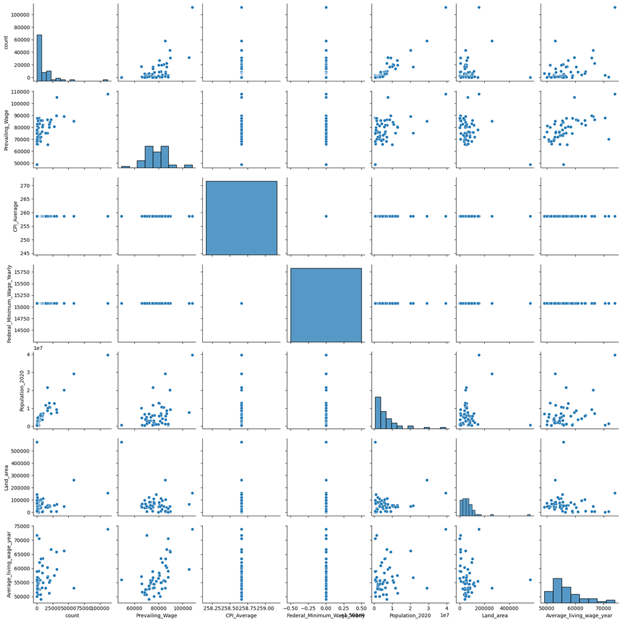

```python
sns.pairplot(min_wage_H1B_living_wage_numeric_data[['count',
                                                    'Prevailing_Wage',
                                                    'CPI_Average',
                                                    'Federal_Minimum_Wage_Yearly',
                                                    'Population_2020',
                                                    'Land_area',
                                                    'Average_living_wage_year']])
```

Use pair plot to see the correlation between visa application count, prevailing wage, average cpi, federal minimum wage, population 2020, land area, average living wage.

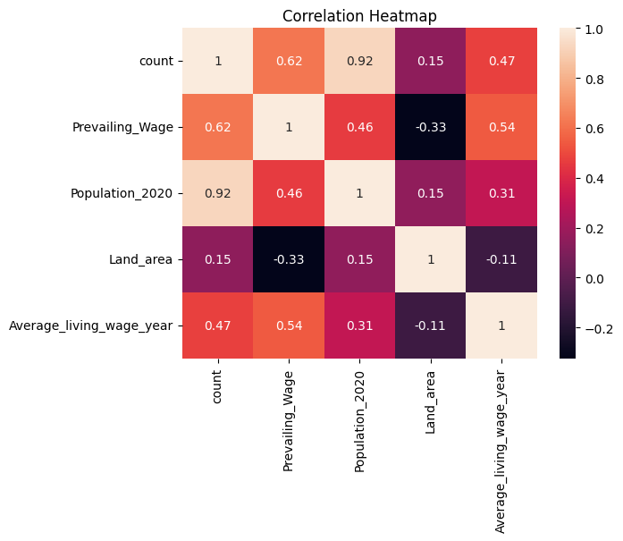

```python
min_wage_H1B_living_wage_numeric_data[['count', 'Prevailing_Wage', 'Population_2020', 'Land_area', 'Average_living_wage_year']]

sns.heatmap(min_wage_H1B_living_wage_numeric_data[['count',
                                                   'Prevailing_Wage',
                                                   'Population_2020',
                                                   'Land_area',
                                                   'Average_living_wage_year']].corr(), annot=True)

# title
plt.title('Correlation Heatmap')
```

The correlation between the number of visa applications and poplation_2020 is 0.92, which is very high and it suggests that the number of visa applications is highly correlated with the population_2020. This is not surprising as the number of visa applications is expected to be higher in states with higher population.

```python
min_wage_H1B_living_wage_numeric_data.columns
```

```
Index(['Worksite_state', 'count', 'Prevailing_Wage', 'Unnamed: 0',
       'State_Minimum_Wage', 'State_Minimum_Wage_2020_Dollars',
       'Federal_Minimum_Wage', 'Federal_Minimum_Wage_2020_Dollars',
       'Effective_Minimum_Wage', 'Effective_Minimum_Wage_2020_Dollars',
       'CPI_Average', 'State_Minimum_Wage_Yearly',
       'State_Minimum_Wage_2020_Dollars_Yearly', 'Federal_Minimum_Wage_Yearly',
       'Federal_Minimum_Wage_2020_Dollars_Yearly',
       'Effective_Minimum_Wage_Yearly',
       'Effective_Minimum_Wage_2020_Dollars_Yearly', 'Population_2020',
       'Land_area', 'Population_density', 'Oneadult_nokids', 'Oneadult_onekid',
       'Oneadult_twokids', 'Oneadult_threekids', 'Twoadults_oneworking_nokids',
       'Twoadults_oneworking_onekid', 'Twoadults_oneworking_twokids',
       'Twoadults_oneworking_threekids', 'Twoadults_bothworking_nokids',
       'Twoadults_bothworking_onekid', 'Twoadults_bothworking_twokids',
       'Twoadults_bothworking_threekids', 'Average_living_wage',
       'Average_living_wage_year'],
      dtype='object')
```

```python
wage_corr_data = State_H1B_Wage_2020_data[['count', 'Effective_Minimum_Wage_2020_Dollars_Yearly',
       'Average_living_wage_year']]

wage_corr_data.rename(columns={
    'count': 'count',
    'Effective_Minimum_Wage_2020_Dollars_Yearly': 'Minimum_Wage',
    'Average_living_wage_year': 'Living_Wage'
}, inplace=True)
```

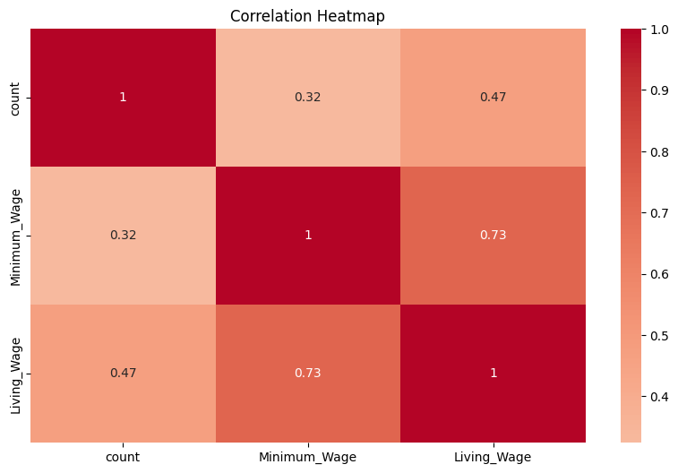

```python
wage_corr_data.corr()
# Create a heatmap
plt.figure(figsize=(10, 6))
sns.heatmap(wage_corr_data.corr(), annot=True, cmap='coolwarm', center=0)
plt.title('Correlation Heatmap')
```

The correlation between average living wage and minimum living wage is 0.73, which is high and it suggests that average living wage is highly correlated with minimum living wage.

1. The finding of trends in descriptive statistic

```python
State_H1B_Wage_2020_data['ratio_average_to_count'] = State_H1B_Wage_2020_data['Effective_Minimum_Wage_2020_Dollars_Yearly'] / State_H1B_Wage_2020_data['count']
State_H1B_Wage_2020_data['ratio_effective_to_count'] = State_H1B_Wage_2020_data['Average_living_wage_year'] / State_H1B_Wage_2020_data['count']
```

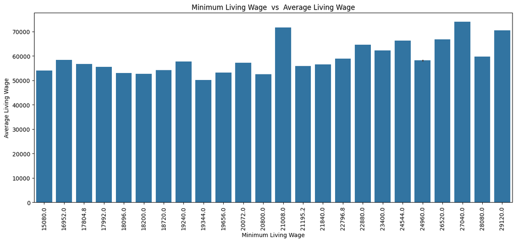

```python
plt.figure(figsize=(15, 6))
sns.barplot(x='Effective_Minimum_Wage_2020_Dollars_Yearly',
            y='Average_living_wage_year',
            data=merge_min_wage_H1B_living_wage.round(2).sort_values('Effective_Minimum_Wage_2020_Dollars_Yearly',
                                                                     ascending=False))
plt.title('Minimum Living Wage  vs  Average Living Wage')
plt.xticks(rotation=90)
plt.xlabel('Minimum Living Wage')
plt.ylabel('Average Living Wage')
plt.show()
```

In this plot it seems that there is no significant relationship between minimum living wage and average living wage. However, comparing two separately show that there is a relationship between two.

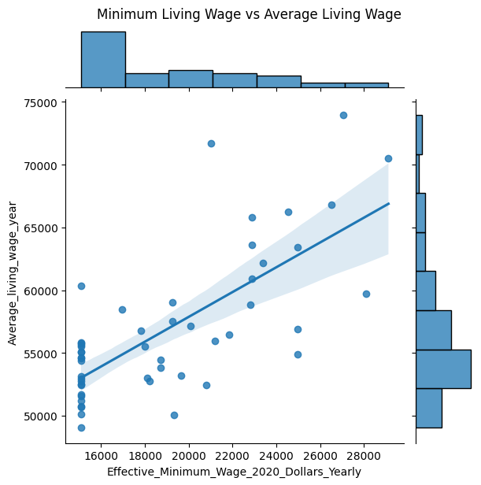

```python
g = sns.JointGrid(data=State_H1B_Wage_2020_data, x='Effective_Minimum_Wage_2020_Dollars_Yearly', y='Average_living_wage_year')
g = g.plot(sns.regplot, sns.histplot)
g.fig.suptitle('Minimum Living Wage vs Average Living Wage', y=1.02)
```

The regression plot suggests that as the minimum wage increases, the average living wage also tends to increase.

2. Seeing the relationship between `H1B_State_Count` and `Average_Living_Wage` graphically.

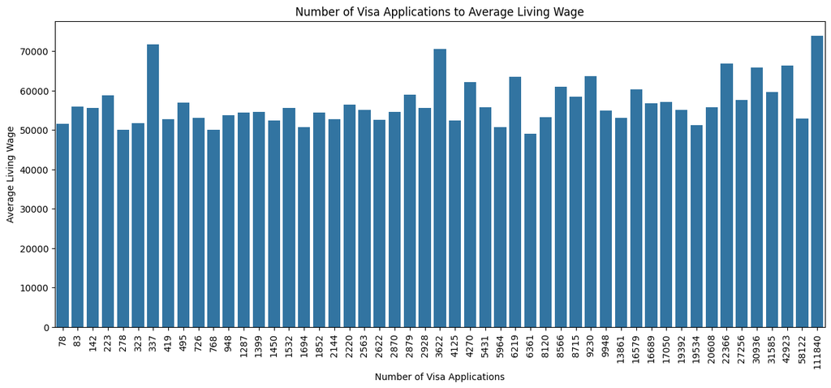

```python
plt.figure(figsize=(15, 6))
sns.barplot(x='count', y='Average_living_wage_year', data=State_H1B_Wage_2020_data.sort_values('count', ascending=False))
plt.xticks(rotation=90)
plt.title('Number of Visa Applications to Average Living Wage')
plt.xlabel('Number of Visa Applications')
plt.ylabel('Average Living Wage')
plt.show()
```

In this plot it seems that there is no significant relationship between Number of Visa Applications and average wage. However, comparing two separately show that there is a relationship between two.

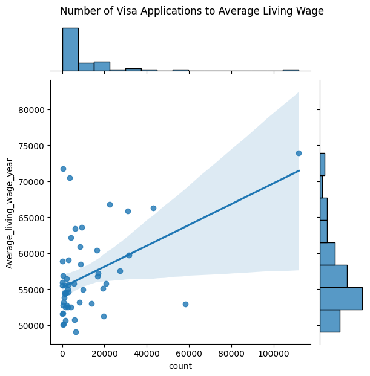

```python
g = sns.JointGrid(data=State_H1B_Wage_2020_data, x='count', y='Average_living_wage_year')
g = g.plot(sns.regplot, sns.histplot)
g.fig.suptitle('Number of Visa Applications to Average Living Wage', y=1.03)
```

The regression plot suggests that as the number of vias application increases, the average living wage also tends to increase.

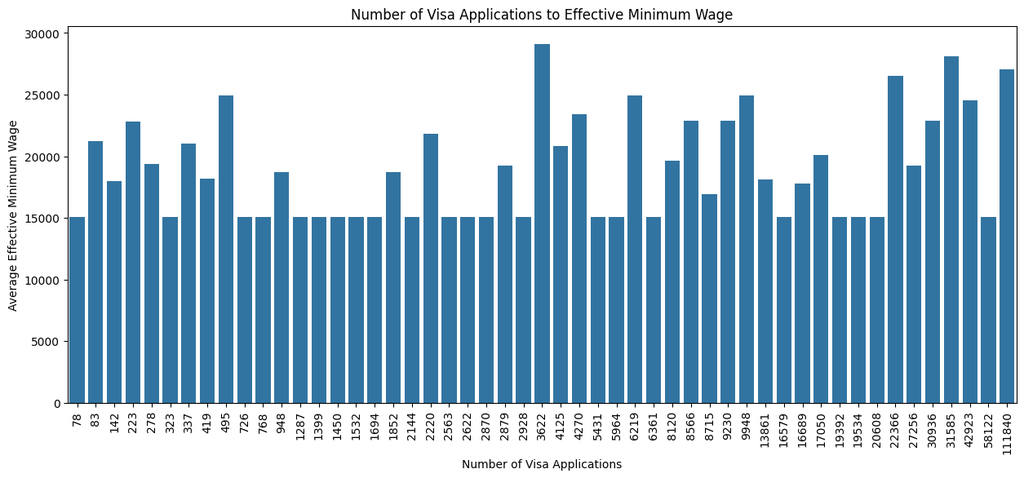

```python
plt.figure(figsize=(15, 6))
sns.barplot(x='count',
            y='Effective_Minimum_Wage_2020_Dollars_Yearly',
            data=State_H1B_Wage_2020_data.sort_values('count', ascending=False))

plt.xticks(rotation=90)
plt.title('Number of Visa Applications to Effective Minimum Wage')
plt.xlabel('Number of Visa Applications')
plt.ylabel('Average Effective Minimum Wage')
```

In this plot it seems that there is no significant relationship between Number of Visa Applications and minimum living wage. However, comparing two separately show that there is a relationship between two.

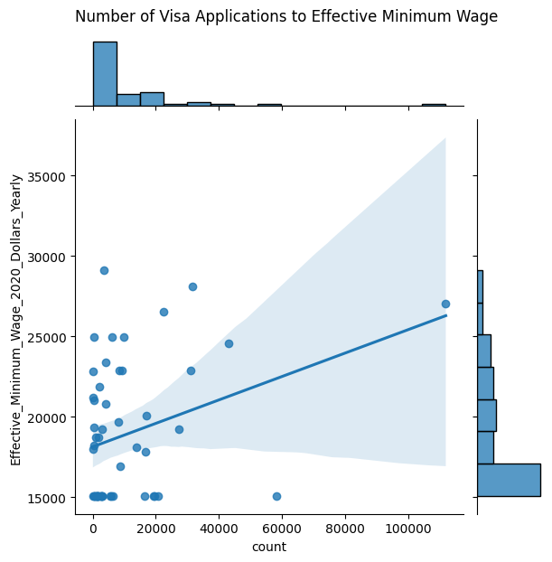

```python
g = sns.JointGrid(data=State_H1B_Wage_2020_data, x='count', y='Effective_Minimum_Wage_2020_Dollars_Yearly')
g = g.plot(sns.regplot, sns.histplot)
g.fig.suptitle('Number of Visa Applications to Effective Minimum Wage', y=1.03)
```

```python
State_H1B_Wage_2020_data.columns
```

```
Index(['Worksite_state', 'count', 'Effective_Minimum_Wage_2020_Dollars_Yearly',
       'Average_living_wage_year', 'ratio_average_to_count',
       'ratio_effective_to_count'],
      dtype='object')
```

Use the linear regression from inferential statistics.

1. Regress `H1B_State_Count` on `Average_Effective_Minimum_Wage` and `Average_Living_Wage`

Checking the Predicted and actual count of the visa application.

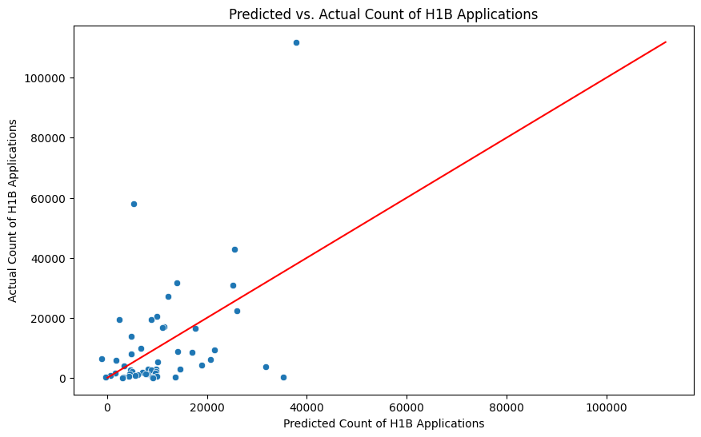

```python
State_H1B_Wage_2020_data['Predicted_Count'] = (-79430
                                               - 0.1946 * State_H1B_Wage_2020_data['Effective_Minimum_Wage_2020_Dollars_Yearly']
                                               + 1.6566 * State_H1B_Wage_2020_data['Average_living_wage_year'])
plt.figure(figsize=(10, 6))
sns.scatterplot(x='Predicted_Count', y='count', data=State_H1B_Wage_2020_data)
plt.plot(State_H1B_Wage_2020_data['count'], State_H1B_Wage_2020_data['count'], color='red')  # Diagonal line for reference
plt.title('Predicted vs. Actual Count of H1B Applications')
plt.xlabel('Predicted Count of H1B Applications')
plt.ylabel('Actual Count of H1B Applications')
plt.show()
```

The plot above suggest that there could be outlier and we should check the residual assumption

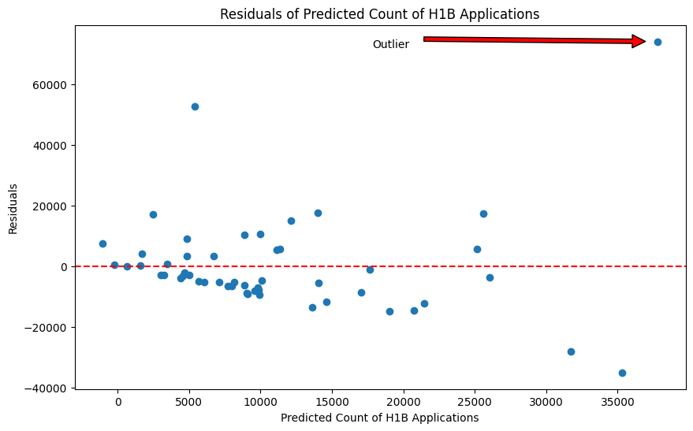

```python
State_H1B_Wage_2020_data['Residuals'] = State_H1B_Wage_2020_data['count'] - State_H1B_Wage_2020_data['Predicted_Count']
# annotate the outliers
x = State_H1B_Wage_2020_data['Predicted_Count']
y = State_H1B_Wage_2020_data['Residuals']

plt.figure(figsize=(10, 6))
plt.scatter(x, y)
plt.axhline(0, color='red', linestyle='--')  # Line at 0 for reference
plt.annotate('Outlier', xy=(x.max(), y.max()), xytext=(x.max() - 20000, y.max() - 2000), arrowprops=dict(facecolor='red', shrink=0.05))

plt.title('Residuals of Predicted Count of H1B Applications')
plt.xlabel('Predicted Count of H1B Applications')
plt.ylabel('Residuals')
plt.show()
```

The plot suggest that there is a point(outlier) which has a much larger residual compared to the other.

Checking the residual normality assumption

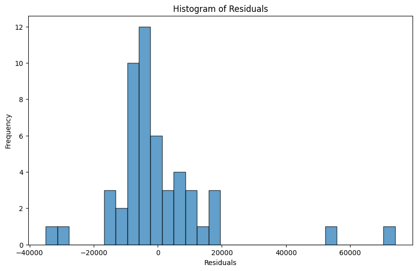

```python
State_H1B_Wage_2020_data['Residuals'] = State_H1B_Wage_2020_data['count'] - State_H1B_Wage_2020_data['Predicted_Count']

plt.figure(figsize=(10, 6))
plt.hist(State_H1B_Wage_2020_data['Residuals'], bins=30, edgecolor='k', alpha=0.7)
plt.title('Histogram of Residuals')
plt.xlabel('Residuals')
plt.ylabel('Frequency')
plt.show()
```

The residual plot shows that the residuals are not normally distributed, and there are some outliers. This indicates that the model is not a good fit for the data. The residuals should be normally distributed and centered around 0 for a good model fit.

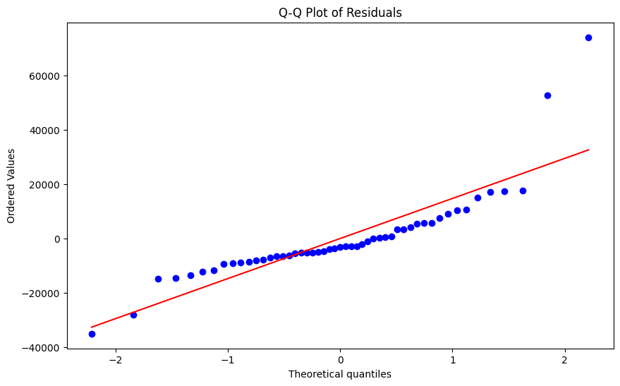

```python
plt.figure(figsize=(10, 6))
stats.probplot(State_H1B_Wage_2020_data['Residuals'], dist="norm", plot=plt)
plt.title('Q-Q Plot of Residuals')
plt.show()
```

Same explanation as above with different approach(Q-Q plot).

```python
stat, p = shapiro(State_H1B_Wage_2020_data['Residuals'])
print('Statistics=%.3f, p=%.3f' % (stat, p))

# Interpretation
alpha = 0.05
if p > alpha:
    print('Sample looks Gaussian (fail to reject H0)')
else:
    print('Sample does not look Gaussian (reject H0)')
```

```
Statistics=0.780, p=0.000
Sample does not look Gaussian (reject H0)
```

The above code is to check the normality of the residuals. The p-value is less than 0.05, so we reject the null hypothesis that the residuals are normally distributed.

Above explains that the residuals are not normally distributed. it suggests that we have to use other method(transformation) to make the residuals normally distributed.

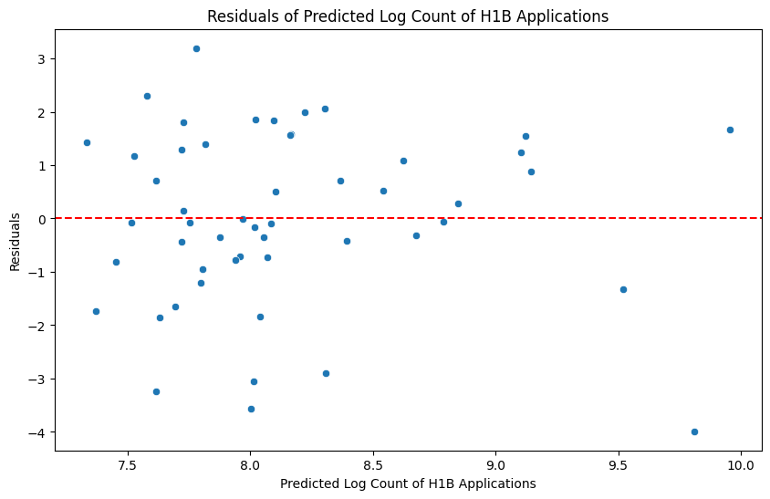

```python
# Apply a log transformation to the count variable and fit the model again
State_H1B_Wage_2020_data['Log_H1B_State_Count'] = np.log(State_H1B_Wage_2020_data['count'] + 1)  # Adding 1 to avoid log(0)

# Now create your model using the log-transformed count
X = State_H1B_Wage_2020_data[['Effective_Minimum_Wage_2020_Dollars_Yearly', 'Average_living_wage_year']]
X = sm.add_constant(X)
y = State_H1B_Wage_2020_data['Log_H1B_State_Count']

model = sm.OLS(y, X).fit()

# Calculate the predicted values and residuals
State_H1B_Wage_2020_data['Predicted_Count'] = model.predict(X)
State_H1B_Wage_2020_data['Residuals'] = State_H1B_Wage_2020_data['Log_H1B_State_Count'] - State_H1B_Wage_2020_data['Predicted_Count']

# Plot the residuals
plt.figure(figsize=(10, 6))
sns.scatterplot(x='Predicted_Count', y='Residuals', data=State_H1B_Wage_2020_data)
plt.axhline(0, color='red', linestyle='--')  # Line at 0 for reference
plt.title('Residuals of Predicted Log Count of H1B Applications')
plt.xlabel('Predicted Log Count of H1B Applications')
plt.ylabel('Residuals')
plt.show()
```

This transformed model's residuals are more normally distributed than the original model's residuals. which suggests that the log transformation has improved the model's fit.

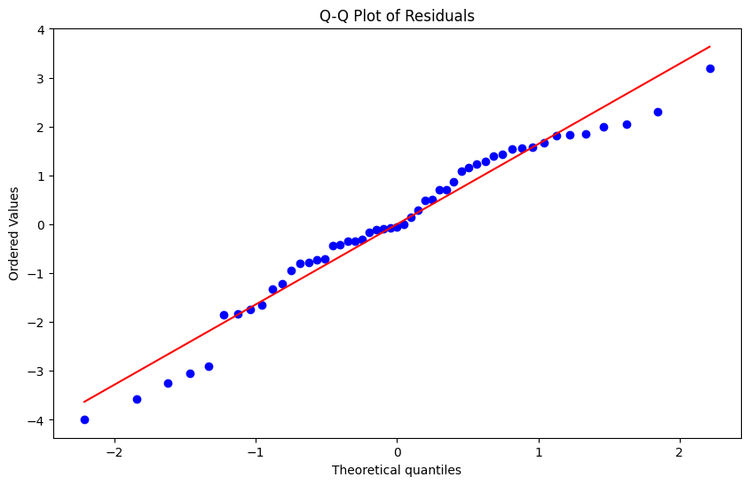

```python
plt.figure(figsize=(10, 6))
stats.probplot(State_H1B_Wage_2020_data['Residuals'], dist="norm", plot=plt)
plt.title('Q-Q Plot of Residuals')
plt.show()
```

Same explanation as above with different approach(Q-Q plot).

```python
stat, p = shapiro(State_H1B_Wage_2020_data['Residuals'])
print('Statistics=%.3f, p=%.3f' % (stat, p))

# Interpretation
alpha = 0.05
if p > alpha:
    print('Sample looks Gaussian (fail to reject H0)')
else:
    print('Sample does not look Gaussian (reject H0)')
```

```
Statistics=0.964, p=0.124
Sample looks Gaussian (fail to reject H0)
```

Use the linear regression from inferential statistics.

2. Regress `H1B_State_Count` on all predictors

```python
min_wage_H1B_living_wage_numeric_data['Predicted_H1B_State_Count'] = (
    0.4847 * min_wage_H1B_living_wage_numeric_data['Prevailing_Wage']
    - 0.0361 * min_wage_H1B_living_wage_numeric_data['CPI_Average']
    - 2.1058 * min_wage_H1B_living_wage_numeric_data['Federal_Minimum_Wage_Yearly']
    + 0.0019 * min_wage_H1B_living_wage_numeric_data['Population_2020']
    + 0.0289 * min_wage_H1B_living_wage_numeric_data['Land_area']
    + 0.3901 * min_wage_H1B_living_wage_numeric_data['Average_living_wage_year']
)

# Calculate the residuals
min_wage_H1B_living_wage_numeric_data['Residuals'] = (
    min_wage_H1B_living_wage_numeric_data['count'] - min_wage_H1B_living_wage_numeric_data['Predicted_H1B_State_Count']
)
```

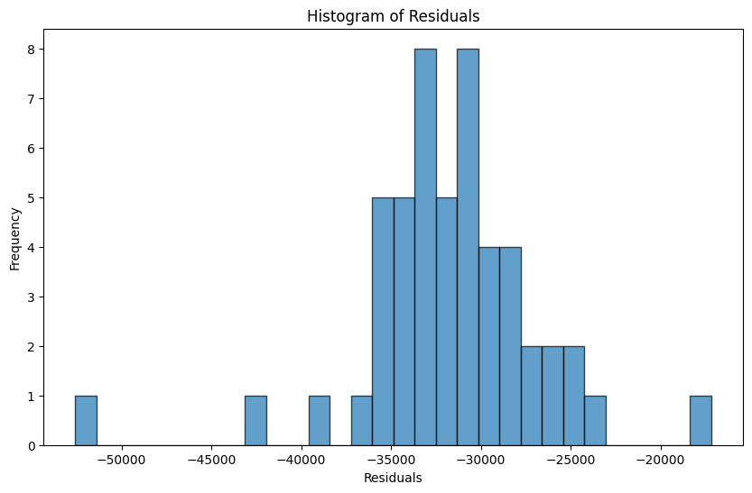

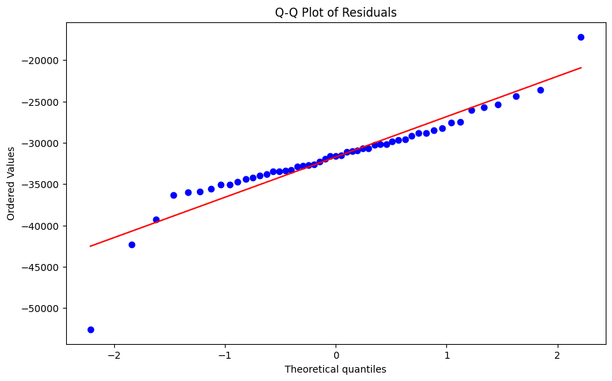

```python
# Histogram
plt.figure(figsize=(10, 6))
plt.hist(min_wage_H1B_living_wage_numeric_data['Residuals'], bins=30, edgecolor='k', alpha=0.7)
plt.title('Histogram of Residuals')
plt.xlabel('Residuals')
plt.ylabel('Frequency')
plt.show()

# Q-Q Plot
plt.figure(figsize=(10, 6))
stats.probplot(min_wage_H1B_living_wage_numeric_data['Residuals'], dist="norm", plot=plt)
plt.title('Q-Q Plot of Residuals')
plt.show()
```

This residual plot is not normal which suggests that the model is not a good fit for the data. As a result, we have to find another model or transformation function that fits the data better.

```python
stat, p = shapiro(min_wage_H1B_living_wage_numeric_data['Residuals'])
print('Statistics=%.3f, p=%.3f' % (stat, p))

# Interpretation
alpha = 0.05
if p > alpha:
    print('Sample looks Gaussian (fail to reject H0)')
else:
    print('Sample does not look Gaussian (reject H0)')
```

```
Statistics=0.900, p=0.000
Sample does not look Gaussian (reject H0)
```

Log transformation of the count variable

```python
# Check for non-positive values
if (min_wage_H1B_living_wage_numeric_data['Residuals'] <= 0).any():
    # Add a constant to shift all residuals to positive values before the log transformation
    min_wage_H1B_living_wage_numeric_data['Residuals_Positive'] = min_wage_H1B_living_wage_numeric_data['Residuals'] - min_wage_H1B_living_wage_numeric_data['Residuals'].min() + 1
else:
    min_wage_H1B_living_wage_numeric_data['Residuals_Positive'] = min_wage_H1B_living_wage_numeric_data['Residuals']

# Apply the log transformation
min_wage_H1B_living_wage_numeric_data['Log_Residuals'] = np.log(min_wage_H1B_living_wage_numeric_data['Residuals_Positive'])
```

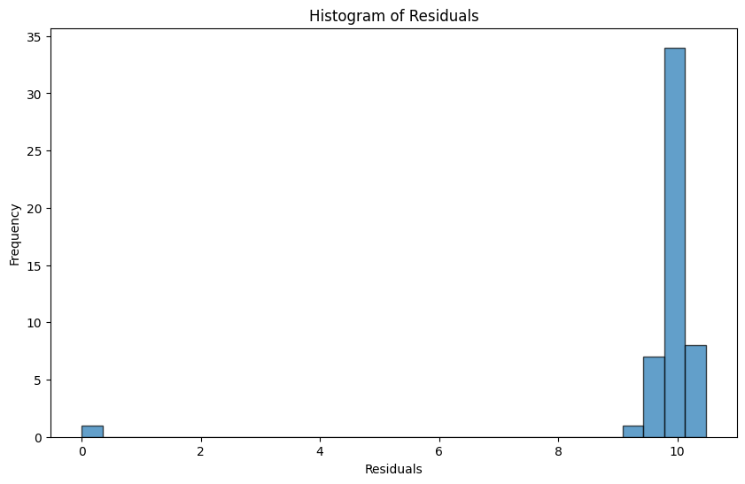

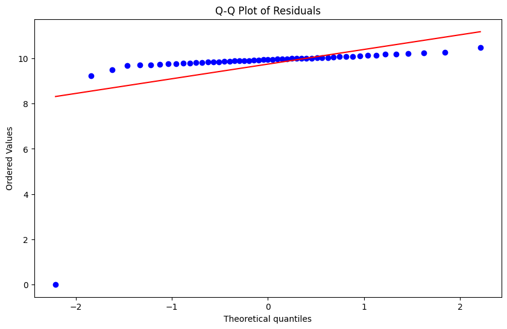

```python
# Histogram
plt.figure(figsize=(10, 6))
plt.hist(min_wage_H1B_living_wage_numeric_data['Log_Residuals'], bins=30, edgecolor='k', alpha=0.7)
plt.title('Histogram of Residuals')
plt.xlabel('Residuals')
plt.ylabel('Frequency')
plt.show()

# Q-Q Plot
plt.figure(figsize=(10, 6))
stats.probplot(min_wage_H1B_living_wage_numeric_data['Log_Residuals'], dist="norm", plot=plt)
plt.title('Q-Q Plot of Residuals')
plt.show()
```

The log transformation has not improved the normality of the residuals. The residuals are still not normally distributed. so we should consider other models or transformations like box-cox transformation.

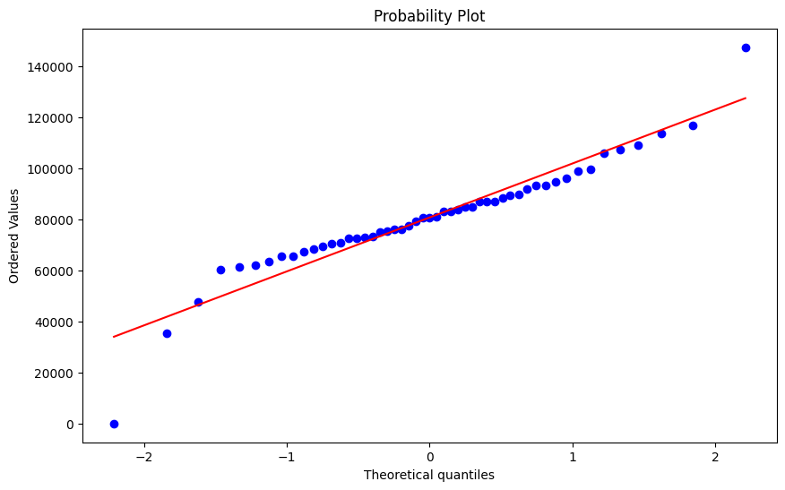

```
Sample does not look Gaussian (reject H0)
```

```python
positive_residuals = min_wage_H1B_living_wage_numeric_data['Residuals'] - min_wage_H1B_living_wage_numeric_data['Residuals'].min() + 1

# Find the best lambda for the Box-Cox transformation
fitted_data, fitted_lambda = stats.boxcox(positive_residuals)

# Apply the Box-Cox transformation with the best found lambda
min_wage_H1B_living_wage_numeric_data['Box_Cox_Residuals'] = stats.boxcox(positive_residuals, lmbda=fitted_lambda)

# Check the normality of the new transformed residuals
plt.figure(figsize=(10, 6))
stats.probplot(min_wage_H1B_living_wage_numeric_data['Box_Cox_Residuals'], dist="norm", plot=plt)
plt.show()

# Perform the Shapiro-Wilk test on the transformed residuals
stat, p = shapiro(min_wage_H1B_living_wage_numeric_data['Box_Cox_Residuals'])
alpha = 0.05
if p > alpha:
    print('Sample looks Gaussian (fail to reject H0)')
else:
    print('Sample does not look Gaussian (reject H0)')
```

Box-cox transformation is not suitable for the residuals either. which suggests that we should consider other robust models which are not sensitive to outliers.

## Comparative Analysis

Here, we want to analyze whether the trend in the number of H1b applications and the average salary are correlated, and to conduct a comparative analysis based on the number of applications for specific SOC positions.

### H1b Applications versus Average Salary

First, we want to compare the number of H1b applications with the mean salary over the years.

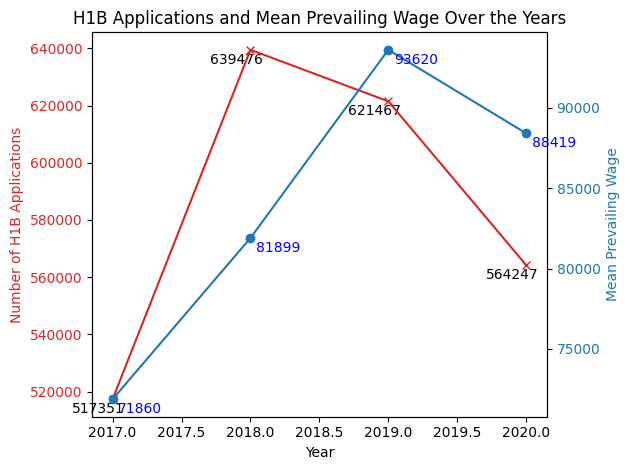

```python
# Count the number of H1B applications over the years
h1b_count = H1B_USA.groupby('Year').size()

# Calculate the mean Prevailing_Wage for each year
mean_wage = H1B_USA.groupby('Year')['Prevailing_Wage'].mean()

# Assuming h1b_count and mean_wage are Pandas Series with the same index.

fig, ax1 = plt.subplots()

# Plot the line for mean wage on the secondary y-axis
ax2 = ax1.twinx()
ax2.plot(mean_wage.index, mean_wage, marker = 'o', color='tab:blue', zorder=1)
ax2.set_ylabel('Mean Prevailing Wage', color='tab:blue')
ax2.tick_params(axis='y', labelcolor='tab:blue')

# Annotate each point for mean wage
for i, wage in enumerate(mean_wage):
    ax2.annotate(f'{wage:.0f}', (mean_wage.index[i], wage), textcoords="offset points", xytext=(20,-10), ha='center', color = 'blue')

# Plot the line for H1B application count on the primary y-axis
ax1.plot(h1b_count.index, h1b_count, marker = 'x',color='tab:red', zorder=10)
ax1.set_xlabel('Year')
ax1.set_ylabel('Number of H1B Applications', color='tab:red')
ax1.tick_params(axis='y', labelcolor='tab:red')

# Annotate each point for H1B application count
for i, count in enumerate(h1b_count):
    ax1.annotate(f'{count}', (h1b_count.index[i], count), textcoords="offset points", xytext=(-10,-10), ha='center')

# Set the title and layout
plt.title('H1B Applications and Mean Prevailing Wage Over the Years')
fig.tight_layout()

# Show the plot
plt.show()
```

Then, we want to see the top 5 most applications SOC_Title.

```python
# Group by 'Year', then apply value_counts to 'SOC_Title', and take the top 5 for each group
top_soc_titles = H1B_USA.groupby('Year')['SOC_Title'].apply(lambda x: x.value_counts().head(5))
```

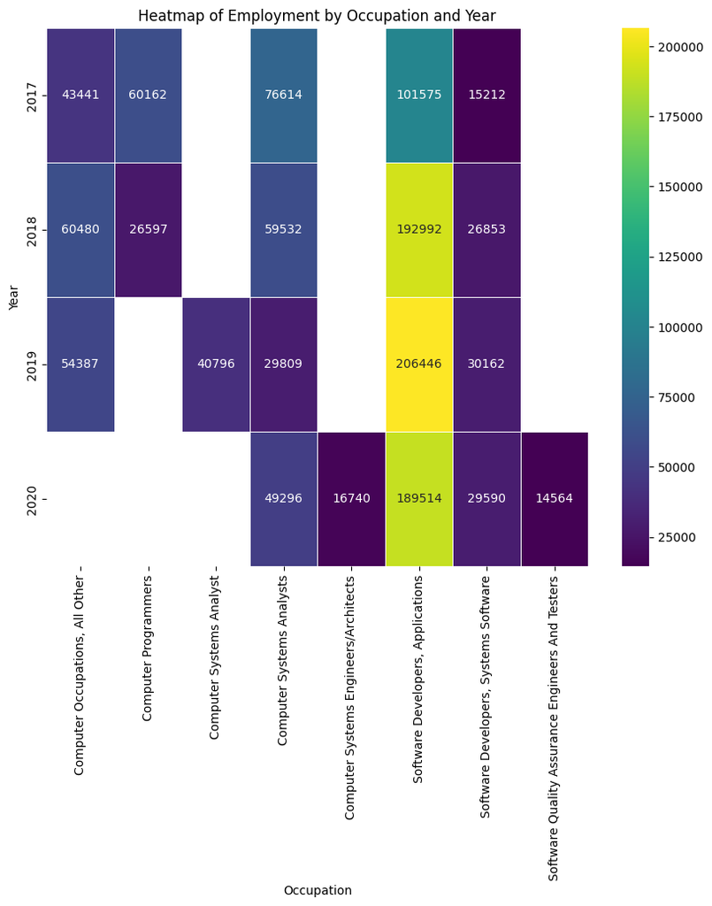

```python
df = top_soc_titles.unstack()

# Let's use Seaborn to create a heatmap.
plt.figure(figsize=(10, 8))
sns.heatmap(df, annot=True, fmt=".0f", cmap="viridis", linewidths=.5)

# Show the heatmap
plt.title('Heatmap of Employment by Occupation and Year')
plt.xlabel('Occupation')
plt.ylabel('Year')
plt.show()
```

```python
only_SDA = merge_min_wage_H1B_first[merge_min_wage_H1B_first['SOC_Title'] == 'Software Developers, Applications']
only_SDA
```

|  | Employer_Name | SOC_Title | Job_Title | Full_Time_Position | Worksite | Prevailing_Wage | Unit_Of_Pay | Employer_Location | Case_Status | Year | ... | Federal_Minimum_Wage_2020_Dollars | Effective_Minimum_Wage | Effective_Minimum_Wage_2020_Dollars | CPI_Average | State_Minimum_Wage_Yearly | State_Minimum_Wage_2020_Dollars_Yearly | Federal_Minimum_Wage_Yearly | Federal_Minimum_Wage_2020_Dollars_Yearly | Effective_Minimum_Wage_Yearly | Effective_Minimum_Wage_2020_Dollars_Yearly |
| --- | --- | --- | --- | --- | --- | --- | --- | --- | --- | --- | --- | --- | --- | --- | --- | --- | --- | --- | --- | --- | --- |
| 13 | ADVANCED TECHNOLOGY GROUP USA INC | Software Developers, Applications | SOFTWARE DEVELOPER | Y | New Brunswick, New Jersey | 63877.0 | Year | Plainsboro, New Jersey | CERTIFIED-WITHDRAWN | 2017 | ... | 7.65 | 8.44 | 8.91 | 245.12 | 17555.2 | 18532.8 | 15080.0 | 15912.0 | 17555.2 | 18532.8 |
| 15 | ADVANCED TECHNOLOGY GROUP USA INC | Software Developers, Applications | SOFTWARE DEVELOPER | Y | New Brunswick, New Jersey | 63877.0 | Year | Plainsboro, New Jersey | CERTIFIED-WITHDRAWN | 2017 | ... | 7.65 | 8.44 | 8.91 | 245.12 | 17555.2 | 18532.8 | 15080.0 | 15912.0 | 17555.2 | 18532.8 |
| 23 | GIMMAL LLC | Software Developers, Applications | MANAGING CONSULTANT - SHAREPOINT DEVELOPER | Y | Houston, Texas | 77875.0 | Year | Houston, Texas | CERTIFIED-WITHDRAWN | 2017 | ... | 7.65 | 7.25 | 7.65 | 245.12 | 15080.0 | 15912.0 | 15080.0 | 15912.0 | 15080.0 | 15912.0 |
| 25 | PLANTRONICS, INC. | Software Developers, Applications | SOFTWARE ENGINEER | Y | Austin, Texas | 66331.0 | Year | Santa Cruz, California | CERTIFIED-WITHDRAWN | 2017 | ... | 7.65 | 7.25 | 7.65 | 245.12 | 15080.0 | 15912.0 | 15080.0 | 15912.0 | 15080.0 | 15912.0 |
| 34 | CAREMARK, LLC | Software Developers, Applications | JAVA DEVELOPER | Y | Buffalo Grove, Illinois | 50128.0 | Year | Irving, Texas | CERTIFIED-WITHDRAWN | 2017 | ... | 7.65 | 8.25 | 8.71 | 245.12 | 17160.0 | 18116.8 | 15080.0 | 15912.0 | 17160.0 | 18116.8 |
| ... | ... | ... | ... | ... | ... | ... | ... | ... | ... | ... | ... | ... | ... | ... | ... | ... | ... | ... | ... | ... | ... |
| 2342532 | THEMESOFT INC. | Software Developers, Applications | Software Engineer | Y | Carlsbad, California | 47.4 | Hour | Plano, Texas | Withdrawn | 2020 | ... | 7.25 | 13.00 | 13.00 | 258.66 | 27040.0 | 27040.0 | 15080.0 | 15080.0 | 27040.0 | 27040.0 |
| 2342534 | SALIGRAM SYSTEMS INC. | Software Developers, Applications | SOFTWARE DEVELOPER | Y | Tulsa, Oklahoma | 69992.0 | Year | Plainsboro, New Jersey | Withdrawn | 2020 | ... | 7.25 | 7.25 | 7.25 | 258.66 | 4160.0 | 4160.0 | 15080.0 | 15080.0 | 15080.0 | 15080.0 |
| 2342535 | TechDemocracy, LLC | Software Developers, Applications | Software Engineer | Y | Glen Allen, Virginia | 42.3 | Hour | Piscataway, New Jersey | Withdrawn | 2020 | ... | 7.25 | 7.25 | 7.25 | 258.66 | 15080.0 | 15080.0 | 15080.0 | 15080.0 | 15080.0 | 15080.0 |
| 2342536 | TechDemocracy, LLC | Software Developers, Applications | Software Enginerr | Y | Glen Allen, Virginia | 42.3 | Hour | Piscataway, New Jersey | Withdrawn | 2020 | ... | 7.25 | 7.25 | 7.25 | 258.66 | 15080.0 | 15080.0 | 15080.0 | 15080.0 | 15080.0 | 15080.0 |
| 2342540 | Altran U.S. Corporation | Software Developers, Applications | Software Engineer | Y | Burlington, Massachusetts | 96242.0 | Year | Burlington, Massachusetts | Withdrawn | 2020 | ... | 7.25 | 12.75 | 12.75 | 258.66 | 26520.0 | 26520.0 | 15080.0 | 15080.0 | 26520.0 | 26520.0 |

690527 rows × 29 columns

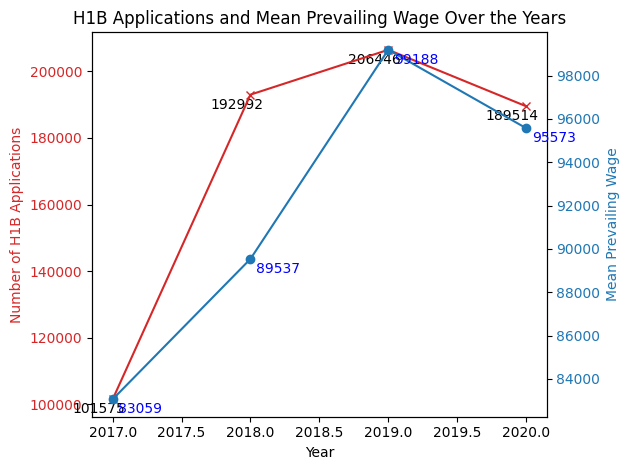

```python
# Count the number of H1B applications over the years
h1b_count = only_SDA.groupby('Year').size()

# Calculate the mean Prevailing_Wage for each year
mean_wage = only_SDA.groupby('Year')['Prevailing_Wage'].mean()

# Assuming h1b_count and mean_wage are Pandas Series with the same index.

fig, ax1 = plt.subplots()

# Plot the line for mean wage on the secondary y-axis
ax2 = ax1.twinx()
ax2.plot(mean_wage.index, mean_wage, marker = 'o', color='tab:blue', zorder=1)
ax2.set_ylabel('Mean Prevailing Wage', color='tab:blue')
ax2.tick_params(axis='y', labelcolor='tab:blue')

# Annotate each point for mean wage
for i, wage in enumerate(mean_wage):
    ax2.annotate(f'{wage:.0f}', (mean_wage.index[i], wage), textcoords="offset points", xytext=(20,-10), ha='center', color = 'blue')

# Plot the line for H1B application count on the primary y-axis
ax1.plot(h1b_count.index, h1b_count, marker = 'x',color='tab:red', zorder=10)
ax1.set_xlabel('Year')
ax1.set_ylabel('Number of H1B Applications', color='tab:red')
ax1.tick_params(axis='y', labelcolor='tab:red')

# Annotate each point for H1B application count
for i, count in enumerate(h1b_count):
    ax1.annotate(f'{count}', (h1b_count.index[i], count), textcoords="offset points", xytext=(-10,-10), ha='center')

# Set the title and layout
plt.title('H1B Applications and Mean Prevailing Wage Over the Years')
fig.tight_layout()

# Show the plot
plt.show()
```

For 'Software Developers, Applications', we observe that its Mean Prevailing Wage over the years mirrors the trend of the overall one. However, its H1B Applications experienced a slight increase from 2018 to 2019, whereas the overall applications saw a decrease during the same period.

```python
top_soc_titles.unstack()
```

| Year | Computer Occupations, All Other | Computer Programmers | Computer Systems Analyst | Computer Systems Analysts | Computer Systems Engineers/Architects | Software Developers, Applications | Software Developers, Systems Software | Software Quality Assurance Engineers And Testers |
| --- | --- | --- | --- | --- | --- | --- | --- | --- |
| 2017 | 43441.0 | 60162.0 | NaN | 76614.0 | NaN | 101575.0 | 15212.0 | NaN |
| 2018 | 60480.0 | 26597.0 | NaN | 59532.0 | NaN | 192992.0 | 26853.0 | NaN |
| 2019 | 54387.0 | NaN | 40796.0 | 29809.0 | NaN | 206446.0 | 30162.0 | NaN |
| 2020 | NaN | NaN | NaN | 49296.0 | 16740.0 | 189514.0 | 29590.0 | 14564.0 |

```python
only_SDSS = merge_min_wage_H1B_first[merge_min_wage_H1B_first['SOC_Title'] == 'Software Developers, Systems Software']
```

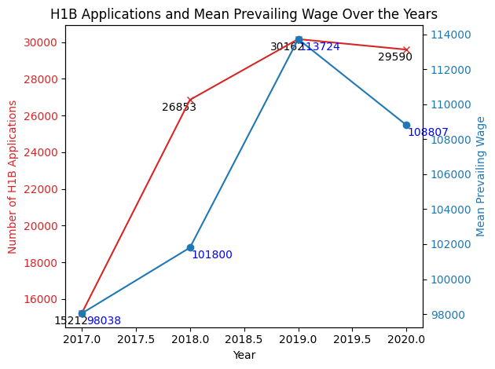

```python
# Count the number of H1B applications over the years
h1b_count = only_SDSS.groupby('Year').size()

# Calculate the mean Prevailing_Wage for each year
mean_wage = only_SDSS.groupby('Year')['Prevailing_Wage'].mean()


# Assuming h1b_count and mean_wage are Pandas Series with the same index.

fig, ax1 = plt.subplots()

# Plot the line for mean wage on the secondary y-axis
ax2 = ax1.twinx()
ax2.plot(mean_wage.index, mean_wage, marker = 'o', color='tab:blue', zorder=1)
ax2.set_ylabel('Mean Prevailing Wage', color='tab:blue')
ax2.tick_params(axis='y', labelcolor='tab:blue')

# Annotate each point for mean wage
for i, wage in enumerate(mean_wage):
    ax2.annotate(f'{wage:.0f}', (mean_wage.index[i], wage), textcoords="offset points", xytext=(20,-10), ha='center', color = 'blue')

# Plot the line for H1B application count on the primary y-axis
ax1.plot(h1b_count.index, h1b_count, marker = 'x',color='tab:red', zorder=10)
ax1.set_xlabel('Year')
ax1.set_ylabel('Number of H1B Applications', color='tab:red')
ax1.tick_params(axis='y', labelcolor='tab:red')

# Annotate each point for H1B application count
for i, count in enumerate(h1b_count):
    ax1.annotate(f'{count}', (h1b_count.index[i], count), textcoords="offset points", xytext=(-10,-10), ha='center')

# Set the title and layout
plt.title('H1B Applications and Mean Prevailing Wage Over the Years')
fig.tight_layout()

# Show the plot
plt.show()
```

Regarding 'Software Developers, Systems Software', the plot also demonstrates a trend similar to the previous one but distinct from the overall trend. And its mean salary is higher than previous two categories.

```python
excluded_titles = ['Software Developers, Systems Software', 'Software Developers, Applications']
other = merge_min_wage_H1B_first[~merge_min_wage_H1B_first['SOC_Title'].isin(excluded_titles)]
```

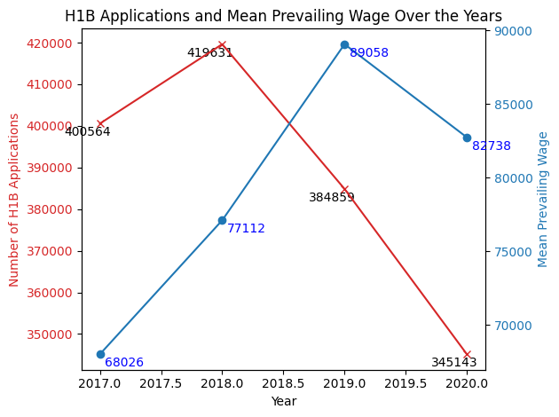

```python
# Count the number of H1B applications over the years
h1b_count = other.groupby('Year').size()

# Calculate the mean Prevailing_Wage for each year
mean_wage = other.groupby('Year')['Prevailing_Wage'].mean()

# Assuming h1b_count and mean_wage are Pandas Series with the same index.

fig, ax1 = plt.subplots()

# Plot the line for mean wage on the secondary y-axis
ax2 = ax1.twinx()
ax2.plot(mean_wage.index, mean_wage, marker = 'o', color='tab:blue', zorder=1)
ax2.set_ylabel('Mean Prevailing Wage', color='tab:blue')
ax2.tick_params(axis='y', labelcolor='tab:blue')

# Annotate each point for mean wage
for i, wage in enumerate(mean_wage):
    ax2.annotate(f'{wage:.0f}', (mean_wage.index[i], wage), textcoords="offset points", xytext=(20,-10), ha='center', color = 'blue')

# Plot the line for H1B application count on the primary y-axis
ax1.plot(h1b_count.index, h1b_count, marker = 'x',color='tab:red', zorder=10)
ax1.set_xlabel('Year')
ax1.set_ylabel('Number of H1B Applications', color='tab:red')
ax1.tick_params(axis='y', labelcolor='tab:red')

# Annotate each point for H1B application count
for i, count in enumerate(h1b_count):
    ax1.annotate(f'{count}', (h1b_count.index[i], count), textcoords="offset points", xytext=(-10,-10), ha='center')

# Set the title and layout
plt.title('H1B Applications and Mean Prevailing Wage Over the Years')
fig.tight_layout()

# Show the plot
plt.show()
```

From the plot that excludes the previous two job titles, we can prove our infer that other professions are experiencing a significant downward trend.

Here, we also want to know whether the minimum wage has the same trend as the mean salary.

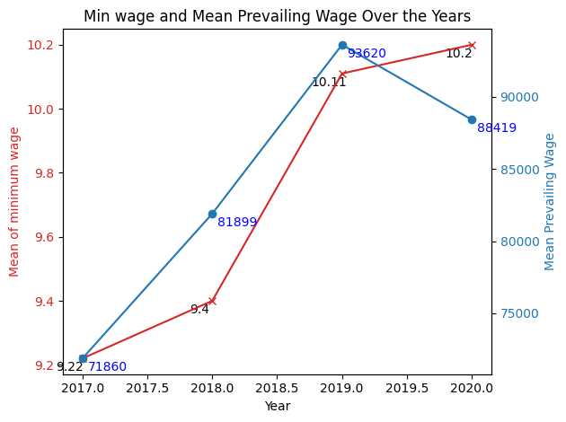

```python
# Calculate the mean Prevailing_Wage for each year
mean_wage = H1B_USA.groupby('Year')['Prevailing_Wage'].mean()
min_wage = merge_min_wage_H1B_first.groupby('Year')['Effective_Minimum_Wage_2020_Dollars'].mean().round(2)

# Assuming h1b_count and mean_wage are Pandas Series with the same index.

fig, ax1 = plt.subplots()

# Plot the line for mean wage on the secondary y-axis
ax2 = ax1.twinx()
ax2.plot(mean_wage.index, mean_wage, marker = 'o', color='tab:blue', zorder=1)
ax2.set_ylabel('Mean Prevailing Wage', color='tab:blue')
ax2.tick_params(axis='y', labelcolor='tab:blue')

# Annotate each point for mean wage
for i, wage in enumerate(mean_wage):
    ax2.annotate(f'{wage:.0f}', (mean_wage.index[i], wage), textcoords="offset points", xytext=(20,-10), ha='center', color = 'blue')

# Plot the line for H1B application count on the primary y-axis
ax1.plot(min_wage.index, min_wage, marker = 'x',color='tab:red', zorder=10)
ax1.set_xlabel('Year')
ax1.set_ylabel('Mean of minimum wage', color='tab:red')
ax1.tick_params(axis='y', labelcolor='tab:red')

# Annotate each point for H1B application count
for i, count in enumerate(min_wage):
    ax1.annotate(f'{count}', (min_wage.index[i], count), textcoords="offset points", xytext=(-10,-10), ha='center')

# Set the title and layout
plt.title('Min wage and Mean Prevailing Wage Over the Years')
fig.tight_layout()

# Show the plot
plt.show()
```

From above we can see that the minimum wage increases over the years while the average wage decreases over after 2019.

## Multivariate Analysis

### Cross-tabulation

This table shows a cross-tabulation of H-1B visa data by state and whether the position is full-time. The rows represent different U.S. states and territories, and the two columns under "H-1B" represent whether the position is not full-time ('N') or full-time ('Y').

```python
# Perform cross-tabulation
cross_tab = pd.crosstab(merge_min_wage_H1B_first['Worksite_state'], [H1B_USA['Visa_Class'], H1B_USA['Full_Time_Position']])

# Display the cross-tabulation
print(cross_tab)
```

```
Visa_Class                H-1B
Full_Time_Position           N       Y
Worksite_state
Alabama                    290    4917
Alaska                      11     434
Arizona                    210   28728
Arkansas                    76   10333
California                8213  336539
Colorado                   217   19055
Connecticut                274   24691
Delaware                   144    9716
District of Columbia       227   11133
Florida                   1163   58194
Georgia                    692   62912
Guam                         7     802
Hawaii                      38    1246
Idaho                       22    2408
Illinois                  1145   86957
Indiana                    437   18035
Iowa                       216    8847
Kansas                     136    7294
Kentucky                   113    7675
Louisiana                   82    4790
Maine                       31    1701
Maryland                   724   29155
Massachusetts             1691   69325
Michigan                  1249   56259
Minnesota                  459   28767
Mississippi                 18    2198
Missouri                   251   24114
Montana                     13     511
Nebraska                    44    6159
Nevada                      73    4075
New Hampshire               50    4447
New Jersey                2372  108686
New Mexico                  96    2664
New York                  6602  137594
North Carolina             345   54593
North Dakota                58    1190
Northern Mariana Islands    13     679
Ohio                       712   43242
Oklahoma                   108    4801
Oregon                     171   12942
Pennsylvania               855   64572
Puerto Rico                  7     768
Rhode Island                79    6595
South Carolina             105    8370
South Dakota                 9     899
Tennessee                  286   19492
Texas                     3026  180055
U.S. Virgin Islands          6     138
Utah                        99    8781
Vermont                     27     993
Virginia                  1191   50393
Washington                 548   80308
West Virginia               75    1346
Wisconsin                  234   17861
Wyoming                     14     354
```

From above table, it shows the number of Full-time or Non Full-time number of H1B applications in each state. Here, we dive in to the most full-time applications and most non-full-time applications state.

```python
# Top 5 non full time applications state
top_non_full_time_states = cross_tab.sort_values(('H-1B', 'N'), ascending=False).head(5)
print(top_non_full_time_states)
```

```
Visa_Class          H-1B
Full_Time_Position     N       Y
Worksite_state
California          8213  336539
New York            6602  137594
Texas               3026  180055
New Jersey          2372  108686
Massachusetts       1691   69325
```

```python
# Top 5 full-time applications state
top_full_time_states = cross_tab.sort_values(('H-1B', 'Y'), ascending=False).head(5)
print(top_full_time_states)
```

```
Visa_Class          H-1B
Full_Time_Position     N       Y
Worksite_state
California          8213  336539
Texas               3026  180055
New York            6602  137594
New Jersey          2372  108686
Illinois            1145   86957
```

From the two tables above, we found that the top four states are almost the same, just in a different order, which includes California, Texas, New Jersey, and New York. However, the fifth state differs, with Illinois having the most full-time applications and Massachusetts having the most non-full-time applications.

Accordingly, we decided to use the percentage of full-time application rate and the percentage of non-full-time application rate. The percentage is calculated as the number of full-time/non-full-time applications divided by the total number of applications.

```python
# Calculate the total number of applications for each state
total_applications = cross_tab.sum(axis=1)

# Calculate the non-full time application rates for each state
non_full_time_rates = cross_tab[('H-1B', 'N')] / total_applications

# Sort the non-full time application rates in descending order
sorted_rates = non_full_time_rates.sort_values(ascending=False)

# Get the top 5 states with the highest non-full time application rates
top_non_full_time_states = sorted_rates.head(5)

# Print the top 5 states
print(top_non_full_time_states)
```

```
Worksite_state
Alabama                0.055694
West Virginia          0.052780
North Dakota           0.046474
New York               0.045785
U.S. Virgin Islands    0.041667
dtype: float64
```

After calculating the percentages of applications, we found that the top 5 states with the highest **non-full-time** application rates are Alabama, West Virginia, North Dakota, New York, and the U.S. Virgin Islands. Here, we observe that only New York appears in both the percentages table and the count table.

How about the states with the highest **full-time application rates**?

```python
# Calculate the total number of applications for each state
total_applications = cross_tab.sum(axis=1)

# Calculate the non-full time application rates for each state
non_full_time_rates = cross_tab[('H-1B', 'Y')] / total_applications

# Sort the non-full time application rates in descending order
sorted_rates = non_full_time_rates.sort_values(ascending=False)

# Get the top 5 states with the highest non-full time application rates
top_non_full_time_states = sorted_rates.head(5)

# Print the top 5 states
print(top_non_full_time_states)
```

```
Worksite_state
North Carolina    0.993720
Washington        0.993223
Nebraska          0.992907
Arizona           0.992743
Arkansas          0.992699
dtype: float64
```

The states with the highest **full-time application rates** are North Carolina, Washington,, Nebraska,Arizona, and Arkansan.

### Pivot tables

```python
# Group by 'Year', then apply value_counts to 'SOC_Title', and take the top 5 for each group
top_soc_titles = H1B_USA.groupby('Year')['SOC_Title'].apply(lambda x: x.value_counts().head(5))
df = top_soc_titles.unstack()
df
```

| Year | Computer Occupations, All Other | Computer Programmers | Computer Systems Analyst | Computer Systems Analysts | Computer Systems Engineers/Architects | Software Developers, Applications | Software Developers, Systems Software | Software Quality Assurance Engineers And Testers |
| --- | --- | --- | --- | --- | --- | --- | --- | --- |
| 2017 | 43441.0 | 60162.0 | NaN | 76614.0 | NaN | 101575.0 | 15212.0 | NaN |
| 2018 | 60480.0 | 26597.0 | NaN | 59532.0 | NaN | 192992.0 | 26853.0 | NaN |
| 2019 | 54387.0 | NaN | 40796.0 | 29809.0 | NaN | 206446.0 | 30162.0 | NaN |
| 2020 | NaN | NaN | NaN | 49296.0 | 16740.0 | 189514.0 | 29590.0 | 14564.0 |

Here we use scatterplot and box plot to analyze the wage scales.

```python
# Remove strange data
max_salary = 1000000
merge_min_wage_H1B_first['Prevailing_Wage'] = merge_min_wage_H1B_first['Prevailing_Wage'].astype(float)
cleaned_main = merge_min_wage_H1B_first[merge_min_wage_H1B_first['Prevailing_Wage'] < max_salary]
```

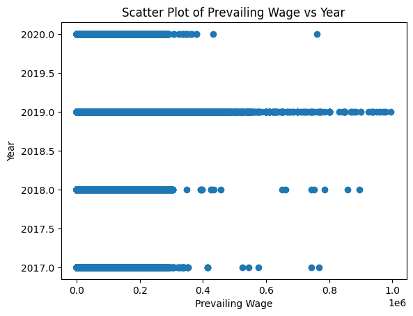

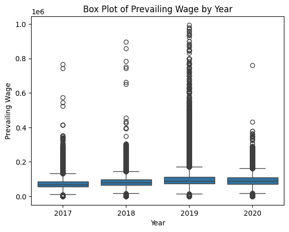

```python
plt.scatter(cleaned_main['Prevailing_Wage'], cleaned_main['Year'])
plt.xlabel('Prevailing Wage')
plt.ylabel('Year')
plt.title('Scatter Plot of Prevailing Wage vs Year')
plt.show()

# Box plot
sns.boxplot(x='Year', y='Prevailing_Wage', data=cleaned_main)
plt.xlabel('Year')
plt.ylabel('Prevailing Wage')
plt.title('Box Plot of Prevailing Wage by Year')
plt.show()
```

The box plot suggests that 2019 stands out with the highest number of outliers in the data set, especially noting that many of these outliers have higher wage values compared to other years. This observation is corroborated by the scatter plot, which visualizes the distribution and highlights these outliers.

With this in mind, it's reasonable to infer that the increased mean prevailing wage in 2019 can be attributed to these outliers. This implies that there were a significant number of H1B applications with wages well above the typical range that year, which skewed the average upwards. Outliers can often have a substantial impact on the mean, especially if they represent high-wage positions. This can provide insights into market anomalies or exceptional demand for certain skills or qualifications in the technology sector during that time.

## Synthesis

The objective of the project is to use the dataset to answer the following question.

1. Will the number of H1B increase, and Living/minimum wage also increase?
2. Given the increase in the U.S. minimum wage in 2020, can we also see a corresponding rise in the living wage?
3. Is the living wage or the minimum wage a better predictor of H1B visa allocations?

#### Findings and conclusion

1. H1B Numbers and Wage Increases:  
   The data did not show a consistent year-over-year increase in H1B visa numbers. Instead, the numbers fluctuated over the years. While there were increases in the effective living wage each year from 2017 to 2020, the number of H1B applications did not consistently increase alongside it, suggesting no strong direct relationship between these two variables. This observation is reinforced by the variance and standard deviation, which indicate that the gap between higher and lower wages is growing.
2. Minimum Wage Increases and Living Wage Response:  
   Analysis of the data for 2020 showed an increase in state minimum wages over the years. Through the correlation test, we found out that the effective wage and living wage have a positive correlation, indicating that the effective wage is related to the living wage data. Thus, state-by-state analysis reveals an upward trend in the state minimum wage.
3. Wage Predictors of H1B Visa Counts:  
   The regression analyses tried to identify whether the living wage or the effective minimum wage is a better predictor of H1B visa allocations. Inferential statistics provided that the average living wage is the more significant variable compared with the effect wage variable. However, while regressing the H1B counts on all variables, we found out that instead of the effective wage, the federal minimum wage is the more significant predictor for the model. Thus, the federal minimum wage will be replaced with the effective minimum wage for further analysis.

## Reflection

1. The regression model might cause some collinearity since their calculation might been somehow similar, thus we believe that machine learning techniques could refine the feature selection to address multicollinearity and overfitting.
2. The living wage data should include the same time range as the H1B dataset so that we can analyze the trend of living wage with H1B salary together.
3. Box-cox transformation is not suitable for the residuals, which suggests that we should consider other robust models that are not sensitive to outliers.